# Diabetes prediction

The goal of this notebook is to elaborate and look into the causes for diabetes. Afterwards a model will be trained to see what are the main factors and it will try and predict what if a person has this health issues.

## Intoroduction

Welcome to this Jupyter Notebook! Our primary objective is to develop a predictive model for identifying the likelihood of diabetes in individuals. This comprehensive analysis will begin with an in-depth exploration of the domain to ensure a thorough understanding of diabetes and its associated risk factors. Following this, we will examine and preprocess the dataset to extract meaningful insights and prepare it for modeling. By combining domain expertise with robust data analysis, we aim to achieve a reliable model that can assist in early diabetes detection and contribute to better health outcomes.

### Importing libraries

```python
import sklearn
import pandas as pd
import seaborn as sns
import matplotlib.pyplot as plt

print("scikit-learn version:", sklearn.__version__) # 1.4.1
print("pandas version:", pd.__version__)            # 2.2.1
print("seaborn version:", sns.__version__)          # 0.13.2
```

```
scikit-learn version: 1.4.1.post1
pandas version: 2.2.2
seaborn version: 0.13.2
```

# **Phase 1**

## Domain Understanding

### 1.What is diabetes?

Diabetes is a chronic medical condition where the body cannot properly regulate blood sugar levels. There are two main types: Type 1 diabetes, where the immune system attacks insulin-producing cells in the pancreas, and Type 2 diabetes, which develops when the body becomes resistant to insulin, or the pancreas cannot produce enough insulin. Both types require careful management to prevent serious health complications. (Diabetes Fonds, n.d.) There are many possible complications that can occur if any type of diabetes is left untreated:

- Type 1 diabetes complications – headaches, dry skin and mouth, stomach pain and without treatment – death (Basina, 2022)
- Type 2 diabetes complications - kidney damage, eye damage, increased risk of hear disease or stroke (UnityPoint Health, n.d.)

By taking this into consideration, it is important to understand the urgency of an available quick evaluation on the possibility of diabetes. With a program where one can insert some of their medical data, which then can be quickly assessed, they can take measures in time and contact a doctor for an appropriate appointment.

### 2.How many people are affected by it?

As of 2021, over 537 million adults aged 20-79 were diagnosed with diabetes, representing one in every ten individuals. This number continues to grow, with projections estimating that by 2045, approximately 783 million people, or one in eight globally, will be affected. These statistics underscore the severity of the situation, highlighting that diabetes is a condition that can affect anyone

Source:

- International Diabetes Assosiation, Diabetes Atlas - https://diabetesatlas.org/

### 3.Causes, risks and symptoms

There is not an exact specific reason considered for the development of diabetes, however there are multiple that are though as the main causes

#### 3.1 Risks and causes

- **Genetics and Family History:** Type 1 diabetes often requires inheriting risk factors from both parents, which are more prevalent among white populations with the highest incidence rates. While most individuals with these genetic predispositions do not develop diabetes, researchers are focused on identifying specific environmental triggers, such as cold weather. Both type 1 and type 2 diabetes share critical factors of genetic predisposition and environmental triggers (About Diabetes, Genetics of Diabetes, n.d.).
- **Age:** The risk of type 2 diabetes significantly increases after the age of 35. Type 1 diabetes, however, can present at any age, with distinct peaks in children aged 4-7 years and 10-14 years.
- **Inactivity and Obesity:** Inactivity and excess weight are significant risk factors for diabetes. Obesity and a sedentary lifestyle further elevate susceptibility. Regular physical activity is crucial for weight management, glucose utilization, and improving cellular sensitivity to insulin.
- **Family members** - Sometimes family members of people with type 1 diabetes are tested for the presence of diabetes immune system cells (autoantibodies). If you have these autoantibodies, you have an increased risk of developing type 1 diabetes. But not everyone who has these autoantibodies develops diabetes.
- **Ethnicity** - Race or ethnicity can also increase the risk of developing type 2 diabetes. Although the reasons are not entirely understood, individuals who are Black, Hispanic, American Indian, or Asian American are at a higher risk.

#### 3.2 Symptoms

• Symptoms for type 1 diabetes include:

```
o   Excessive thirst
o   Frequent urination
o   Bed-wetting in children who previously did not wet the bed at night.
o   Intense hunger
o   Unintentional weight loss
o   Irritability or mood changes
o   Fatigue and weakness
o   Blurry vision
```

• Symptoms for type 2 diabetes include:

```
o	Increased thirst
o	Frequent urination
o	Increased hunger
o	Unintended weight loss
o	Fatigue
o	Blurred vision
o	Slow-healing sores
o	Frequent infections
o	Numbness or tingling in the hands or feet.
o	Areas of darkened skin, usually in the armpits and neck
```

### 4.Treatments

Considering the fact that diabetes is incurable might upset most people and even scare them, that does not mean that it is impossible to treat such a condition:

Treatments for type 1 diabetes: There are 4 possible types of insulin that could be taken so that an individual can live with diabetes:

```
- Short-acting insulin
- Rapid-acting insulin
- Intermediate-acting insulin
- Long- and Ultra- long acting insulin
```

Treatments for type 2 diabetes:

```
- Healthy eating and a balanced diet
- Physical activity
- Weight loss
- Diabetes Medication
```

As we see it is possible to `'fight'` against diabetes and not give up hope, with some adjustments to our livestyles

## INTERESTED IN LEARNING MORE ABOUT DIABETES?

If you want to know more details about:

- What are the differences in the dosages of insulin previously mentioned?
- What are some ways to deliver and monitor insulin?
- How do healthcare system contribute to the struggling agains diabetes?
- How is it being diagnosed?
- How have people dealt with diabetes in the past?

as well as go into more details about the previously discussed topics, feel free to read more about these topics in the project proposal which has been attached to this notebook withing the submission!

# **Phase 2**

## Data Requirments

To achieve such a system, we will need different kinds of mostly medical data, related to the person. Not only that be we would probably need some kind of lifestyle data since it is something that should be taken into consideration, when trying to predict something of this sort. General data would also be nice, something like the gender and age as an example to start with. The BMI also could also be useful since it can be affected by/affect diabetes. Sport activities may be somehow related, since there is research that shows that people who do more physical activity are less likely to develop the illness. Also, blood sugar levels should be of great help when it comes to determining the possibly of development.

- Age – Number
- Gender – Male or Female – 0/1
- BMI – Number
- Smoking – yes/no – 1/0
- Activity – yes/No – 1/0
- Blood Sugat Levels - Number

## Data Collection

After looking around into different possible sources, I have decided to work on this dataset from Kaggle:

https://www.kaggle.com/datasets/rabieelkharoua/diabetes-health-dataset-analysis/data

It seems like it contains a lot of vital data for such a project and it also contains some of the features which were mentioned earlier

### Let us have a deeper look into what we are working with

```python
whole_data = pd.read_csv('dataset/diabetes_data.csv')
```

```python
whole_data.shape
```

```
(1879, 46)
```

```python
whole_data.columns
```

```
Index(['PatientID', 'Age', 'Gender', 'Ethnicity', 'SocioeconomicStatus',
       'EducationLevel', 'BMI', 'Smoking', 'AlcoholConsumption',
       'PhysicalActivity', 'DietQuality', 'SleepQuality',
       'FamilyHistoryDiabetes', 'GestationalDiabetes',
       'PolycysticOvarySyndrome', 'PreviousPreDiabetes', 'Hypertension',
       'SystolicBP', 'DiastolicBP', 'FastingBloodSugar', 'HbA1c',
       'SerumCreatinine', 'BUNLevels', 'CholesterolTotal', 'CholesterolLDL',
       'CholesterolHDL', 'CholesterolTriglycerides',
       'AntihypertensiveMedications', 'Statins', 'AntidiabeticMedications',
       'FrequentUrination', 'ExcessiveThirst', 'UnexplainedWeightLoss',
       'FatigueLevels', 'BlurredVision', 'SlowHealingSores',
       'TinglingHandsFeet', 'QualityOfLifeScore', 'HeavyMetalsExposure',
       'OccupationalExposureChemicals', 'WaterQuality',
       'MedicalCheckupsFrequency', 'MedicationAdherence', 'HealthLiteracy',
       'Diagnosis', 'DoctorInCharge'],
      dtype='object')
```

To make it easier to read

```python
for column in whole_data.columns:
    print(column)
```

```
PatientID
Age
Gender
Ethnicity
SocioeconomicStatus
EducationLevel
BMI
Smoking
AlcoholConsumption
PhysicalActivity
DietQuality
SleepQuality
FamilyHistoryDiabetes
GestationalDiabetes
PolycysticOvarySyndrome
PreviousPreDiabetes
Hypertension
SystolicBP
DiastolicBP
FastingBloodSugar
HbA1c
SerumCreatinine
BUNLevels
CholesterolTotal
CholesterolLDL
CholesterolHDL
CholesterolTriglycerides
AntihypertensiveMedications
Statins
AntidiabeticMedications
FrequentUrination
ExcessiveThirst
UnexplainedWeightLoss
FatigueLevels
BlurredVision
SlowHealingSores
TinglingHandsFeet
QualityOfLifeScore
HeavyMetalsExposure
OccupationalExposureChemicals
WaterQuality
MedicalCheckupsFrequency
MedicationAdherence
HealthLiteracy
Diagnosis
DoctorInCharge
```

```python
whole_data.head()
```

|  | PatientID | Age | Gender | Ethnicity | SocioeconomicStatus | EducationLevel | BMI | Smoking | AlcoholConsumption | PhysicalActivity | ... | TinglingHandsFeet | QualityOfLifeScore | HeavyMetalsExposure | OccupationalExposureChemicals | WaterQuality | MedicalCheckupsFrequency | MedicationAdherence | HealthLiteracy | Diagnosis | DoctorInCharge |
| --- | --- | --- | --- | --- | --- | --- | --- | --- | --- | --- | --- | --- | --- | --- | --- | --- | --- | --- | --- | --- | --- |
| 0 | 6000 | 44 | 0 | 1 | 2 | 1 | 32.985284 | 1 | 4.499365 | 2.443385 | ... | 1 | 73.765109 | 0 | 0 | 0 | 1.782724 | 4.486980 | 7.211349 | 1 | Confidential |
| 1 | 6001 | 51 | 1 | 0 | 1 | 2 | 39.916764 | 0 | 1.578919 | 8.301264 | ... | 0 | 91.445753 | 0 | 0 | 1 | 3.381070 | 5.961705 | 5.024612 | 1 | Confidential |
| 2 | 6002 | 89 | 1 | 0 | 1 | 3 | 19.782251 | 0 | 1.177301 | 6.103395 | ... | 0 | 54.485744 | 0 | 0 | 0 | 2.701019 | 8.950821 | 7.034944 | 0 | Confidential |
| 3 | 6003 | 21 | 1 | 1 | 1 | 2 | 32.376881 | 1 | 1.714621 | 8.645465 | ... | 0 | 77.866758 | 0 | 0 | 1 | 1.409056 | 3.124769 | 4.717774 | 0 | Confidential |
| 4 | 6004 | 27 | 1 | 0 | 1 | 3 | 16.808600 | 0 | 15.462549 | 4.629383 | ... | 0 | 37.731808 | 0 | 0 | 0 | 1.218452 | 6.977741 | 7.887940 | 0 | Confidential |

5 rows × 46 columns

After having a quick look into the `head` of the dataset, it seems like there is only one value for `DoctorInCharge` - *Confidential*. This is understandable since they are trying to keep the confidetiality of the people involved so it would probably be a good idea to drop it

```python
whole_data = whole_data.drop(columns=['DoctorInCharge'])
```

```python
whole_data.isna().sum()
```

```
PatientID                        0
Age                              0
Gender                           0
Ethnicity                        0
SocioeconomicStatus              0
EducationLevel                   0
BMI                              0
Smoking                          0
AlcoholConsumption               0
PhysicalActivity                 0
DietQuality                      0
SleepQuality                     0
FamilyHistoryDiabetes            0
GestationalDiabetes              0
PolycysticOvarySyndrome          0
PreviousPreDiabetes              0
Hypertension                     0
SystolicBP                       0
DiastolicBP                      0
FastingBloodSugar                0
HbA1c                            0
SerumCreatinine                  0
BUNLevels                        0
CholesterolTotal                 0
CholesterolLDL                   0
CholesterolHDL                   0
CholesterolTriglycerides         0
AntihypertensiveMedications      0
Statins                          0
AntidiabeticMedications          0
FrequentUrination                0
ExcessiveThirst                  0
UnexplainedWeightLoss            0
FatigueLevels                    0
BlurredVision                    0
SlowHealingSores                 0
TinglingHandsFeet                0
QualityOfLifeScore               0
HeavyMetalsExposure              0
OccupationalExposureChemicals    0
WaterQuality                     0
MedicalCheckupsFrequency         0
MedicationAdherence              0
HealthLiteracy                   0
Diagnosis                        0
dtype: int64
```

It does also seem like the whole dataset does not have missing values which is useful, however I do believe we should keep an eye out for the possible problems in the future

```python
for col in whole_data.columns:
    print(f"Column '{col}' has {whole_data[col].nunique()} unique values.")
```

```
Column 'PatientID' has 1879 unique values.
Column 'Age' has 71 unique values.
Column 'Gender' has 2 unique values.
Column 'Ethnicity' has 4 unique values.
Column 'SocioeconomicStatus' has 3 unique values.
Column 'EducationLevel' has 4 unique values.
Column 'BMI' has 1879 unique values.
Column 'Smoking' has 2 unique values.
Column 'AlcoholConsumption' has 1879 unique values.
Column 'PhysicalActivity' has 1879 unique values.
Column 'DietQuality' has 1879 unique values.
Column 'SleepQuality' has 1879 unique values.
Column 'FamilyHistoryDiabetes' has 2 unique values.
Column 'GestationalDiabetes' has 2 unique values.
Column 'PolycysticOvarySyndrome' has 2 unique values.
Column 'PreviousPreDiabetes' has 2 unique values.
Column 'Hypertension' has 2 unique values.
Column 'SystolicBP' has 90 unique values.
Column 'DiastolicBP' has 60 unique values.
Column 'FastingBloodSugar' has 1879 unique values.
Column 'HbA1c' has 1879 unique values.
Column 'SerumCreatinine' has 1879 unique values.
Column 'BUNLevels' has 1879 unique values.
Column 'CholesterolTotal' has 1879 unique values.
Column 'CholesterolLDL' has 1879 unique values.
Column 'CholesterolHDL' has 1879 unique values.
Column 'CholesterolTriglycerides' has 1879 unique values.
Column 'AntihypertensiveMedications' has 2 unique values.
Column 'Statins' has 2 unique values.
Column 'AntidiabeticMedications' has 2 unique values.
Column 'FrequentUrination' has 2 unique values.
Column 'ExcessiveThirst' has 2 unique values.
Column 'UnexplainedWeightLoss' has 2 unique values.
Column 'FatigueLevels' has 1879 unique values.
Column 'BlurredVision' has 2 unique values.
Column 'SlowHealingSores' has 2 unique values.
Column 'TinglingHandsFeet' has 2 unique values.
Column 'QualityOfLifeScore' has 1879 unique values.
Column 'HeavyMetalsExposure' has 2 unique values.
Column 'OccupationalExposureChemicals' has 2 unique values.
Column 'WaterQuality' has 2 unique values.
Column 'MedicalCheckupsFrequency' has 1879 unique values.
Column 'MedicationAdherence' has 1879 unique values.
Column 'HealthLiteracy' has 1879 unique values.
Column 'Diagnosis' has 2 unique values.
```

```python
whole_data.head()
```

|  | PatientID | Age | Gender | Ethnicity | SocioeconomicStatus | EducationLevel | BMI | Smoking | AlcoholConsumption | PhysicalActivity | ... | SlowHealingSores | TinglingHandsFeet | QualityOfLifeScore | HeavyMetalsExposure | OccupationalExposureChemicals | WaterQuality | MedicalCheckupsFrequency | MedicationAdherence | HealthLiteracy | Diagnosis |
| --- | --- | --- | --- | --- | --- | --- | --- | --- | --- | --- | --- | --- | --- | --- | --- | --- | --- | --- | --- | --- | --- |
| 0 | 6000 | 44 | 0 | 1 | 2 | 1 | 32.985284 | 1 | 4.499365 | 2.443385 | ... | 0 | 1 | 73.765109 | 0 | 0 | 0 | 1.782724 | 4.486980 | 7.211349 | 1 |
| 1 | 6001 | 51 | 1 | 0 | 1 | 2 | 39.916764 | 0 | 1.578919 | 8.301264 | ... | 0 | 0 | 91.445753 | 0 | 0 | 1 | 3.381070 | 5.961705 | 5.024612 | 1 |
| 2 | 6002 | 89 | 1 | 0 | 1 | 3 | 19.782251 | 0 | 1.177301 | 6.103395 | ... | 0 | 0 | 54.485744 | 0 | 0 | 0 | 2.701019 | 8.950821 | 7.034944 | 0 |
| 3 | 6003 | 21 | 1 | 1 | 1 | 2 | 32.376881 | 1 | 1.714621 | 8.645465 | ... | 0 | 0 | 77.866758 | 0 | 0 | 1 | 1.409056 | 3.124769 | 4.717774 | 0 |
| 4 | 6004 | 27 | 1 | 0 | 1 | 3 | 16.808600 | 0 | 15.462549 | 4.629383 | ... | 0 | 0 | 37.731808 | 0 | 0 | 0 | 1.218452 | 6.977741 | 7.887940 | 0 |

5 rows × 45 columns

There are too many columns to work with, so we will probably create multiple smaller datasets with the different valeues. Also, it would probably be a good idea to keep the whole dataset as well, just in case we may need it.

```python
whole_data.describe()
```

|  | PatientID | Age | Gender | Ethnicity | SocioeconomicStatus | EducationLevel | BMI | Smoking | AlcoholConsumption | PhysicalActivity | ... | SlowHealingSores | TinglingHandsFeet | QualityOfLifeScore | HeavyMetalsExposure | OccupationalExposureChemicals | WaterQuality | MedicalCheckupsFrequency | MedicationAdherence | HealthLiteracy | Diagnosis |
| --- | --- | --- | --- | --- | --- | --- | --- | --- | --- | --- | --- | --- | --- | --- | --- | --- | --- | --- | --- | --- | --- |
| count | 1879.000000 | 1879.000000 | 1879.000000 | 1879.000000 | 1879.000000 | 1879.000000 | 1879.000000 | 1879.000000 | 1879.000000 | 1879.000000 | ... | 1879.000000 | 1879.000000 | 1879.000000 | 1879.000000 | 1879.000000 | 1879.000000 | 1879.000000 | 1879.000000 | 1879.000000 | 1879.000000 |
| mean | 6939.000000 | 55.043108 | 0.487493 | 0.755721 | 0.992017 | 1.699308 | 27.687601 | 0.281533 | 10.096587 | 5.200790 | ... | 0.102714 | 0.111229 | 48.508643 | 0.052155 | 0.103246 | 0.200639 | 1.997101 | 4.957539 | 5.011736 | 0.400213 |
| std | 542.564896 | 20.515839 | 0.499977 | 1.047558 | 0.764940 | 0.885665 | 7.190975 | 0.449866 | 5.914216 | 2.857012 | ... | 0.303666 | 0.314500 | 28.758488 | 0.222400 | 0.304361 | 0.400585 | 1.122632 | 2.910934 | 2.920908 | 0.490072 |
| min | 6000.000000 | 20.000000 | 0.000000 | 0.000000 | 0.000000 | 0.000000 | 15.025898 | 0.000000 | 0.000928 | 0.004089 | ... | 0.000000 | 0.000000 | 0.002390 | 0.000000 | 0.000000 | 0.000000 | 0.004013 | 0.005384 | 0.000362 | 0.000000 |
| 25% | 6469.500000 | 38.000000 | 0.000000 | 0.000000 | 0.000000 | 1.000000 | 21.469981 | 0.000000 | 4.789725 | 2.751022 | ... | 0.000000 | 0.000000 | 23.974098 | 0.000000 | 0.000000 | 0.000000 | 1.057801 | 2.420024 | 2.410113 | 0.000000 |
| 50% | 6939.000000 | 55.000000 | 0.000000 | 0.000000 | 1.000000 | 2.000000 | 27.722988 | 0.000000 | 10.173865 | 5.249002 | ... | 0.000000 | 0.000000 | 47.519693 | 0.000000 | 0.000000 | 0.000000 | 1.987170 | 4.843886 | 5.035208 | 0.000000 |
| 75% | 7408.500000 | 73.000000 | 1.000000 | 1.000000 | 2.000000 | 2.000000 | 33.856460 | 1.000000 | 15.285359 | 7.671402 | ... | 0.000000 | 0.000000 | 72.883179 | 0.000000 | 0.000000 | 0.000000 | 2.946019 | 7.513933 | 7.586865 | 1.000000 |
| max | 7878.000000 | 90.000000 | 1.000000 | 3.000000 | 2.000000 | 3.000000 | 39.998811 | 1.000000 | 19.996231 | 9.993893 | ... | 1.000000 | 1.000000 | 99.788530 | 1.000000 | 1.000000 | 1.000000 | 3.999715 | 9.997165 | 9.993029 | 1.000000 |

8 rows × 45 columns

```python
demographic_details_data = whole_data[['PatientID', 'Age', 'Gender', 'Ethnicity', 'SocioeconomicStatus', 'EducationLevel','Diagnosis']]
print(demographic_details_data.shape)
demographic_details_data.head()
```

```
(1879, 7)
```

|  | PatientID | Age | Gender | Ethnicity | SocioeconomicStatus | EducationLevel | Diagnosis |
| --- | --- | --- | --- | --- | --- | --- | --- |
| 0 | 6000 | 44 | 0 | 1 | 2 | 1 | 1 |
| 1 | 6001 | 51 | 1 | 0 | 1 | 2 | 1 |
| 2 | 6002 | 89 | 1 | 0 | 1 | 3 | 0 |
| 3 | 6003 | 21 | 1 | 1 | 1 | 2 | 0 |
| 4 | 6004 | 27 | 1 | 0 | 1 | 3 | 0 |

```python
lifestyle_data = whole_data[['PatientID', 'BMI', 'Smoking', 'AlcoholConsumption', 'PhysicalActivity', 'DietQuality', 'SleepQuality','Diagnosis']]
print(lifestyle_data.shape)
lifestyle_data.head()
```

```
(1879, 8)
```

|  | PatientID | BMI | Smoking | AlcoholConsumption | PhysicalActivity | DietQuality | SleepQuality | Diagnosis |
| --- | --- | --- | --- | --- | --- | --- | --- | --- |
| 0 | 6000 | 32.985284 | 1 | 4.499365 | 2.443385 | 4.898831 | 4.049885 | 1 |
| 1 | 6001 | 39.916764 | 0 | 1.578919 | 8.301264 | 8.941093 | 7.508150 | 1 |
| 2 | 6002 | 19.782251 | 0 | 1.177301 | 6.103395 | 7.722543 | 7.708387 | 0 |
| 3 | 6003 | 32.376881 | 1 | 1.714621 | 8.645465 | 4.804044 | 6.286548 | 0 |
| 4 | 6004 | 16.808600 | 0 | 15.462549 | 4.629383 | 2.532756 | 9.771125 | 0 |

```python
medical_history_data = whole_data[['PatientID', 'FamilyHistoryDiabetes', 'GestationalDiabetes', 'PolycysticOvarySyndrome', 'PreviousPreDiabetes', 'Hypertension','Diagnosis']]
print(medical_history_data.shape)
medical_history_data.head()
```

```
(1879, 7)
```

|  | PatientID | FamilyHistoryDiabetes | GestationalDiabetes | PolycysticOvarySyndrome | PreviousPreDiabetes | Hypertension | Diagnosis |
| --- | --- | --- | --- | --- | --- | --- | --- |
| 0 | 6000 | 1 | 1 | 0 | 0 | 0 | 1 |
| 1 | 6001 | 0 | 0 | 0 | 0 | 0 | 1 |
| 2 | 6002 | 1 | 0 | 0 | 0 | 0 | 0 |
| 3 | 6003 | 1 | 1 | 0 | 1 | 0 | 0 |
| 4 | 6004 | 0 | 0 | 0 | 0 | 0 | 0 |

```python
clinical_measurements_data = whole_data[['PatientID', 'SystolicBP', 'DiastolicBP', 'FastingBloodSugar', 'HbA1c', 'SerumCreatinine', 'BUNLevels', 'CholesterolTotal', 'CholesterolLDL', 'CholesterolHDL', 'CholesterolTriglycerides','Diagnosis']]
print(clinical_measurements_data.shape)
clinical_measurements_data.head()
```

```
(1879, 12)
```

|  | PatientID | SystolicBP | DiastolicBP | FastingBloodSugar | HbA1c | SerumCreatinine | BUNLevels | CholesterolTotal | CholesterolLDL | CholesterolHDL | CholesterolTriglycerides | Diagnosis |
| --- | --- | --- | --- | --- | --- | --- | --- | --- | --- | --- | --- | --- |
| 0 | 6000 | 93 | 73 | 163.687162 | 9.283631 | 2.665607 | 28.190147 | 254.270670 | 86.993627 | 70.801469 | 190.335834 | 1 |
| 1 | 6001 | 165 | 99 | 188.347070 | 7.326870 | 4.172177 | 32.149491 | 155.358831 | 110.056105 | 39.900112 | 81.172469 | 1 |
| 2 | 6002 | 119 | 91 | 127.703653 | 4.083426 | 1.973168 | 10.018375 | 231.608922 | 62.035793 | 62.480666 | 279.809069 | 0 |
| 3 | 6003 | 169 | 87 | 82.688415 | 6.516645 | 3.057797 | 44.123281 | 176.592374 | 68.238410 | 46.977819 | 112.751396 | 0 |
| 4 | 6004 | 165 | 69 | 90.743395 | 5.607222 | 4.150353 | 7.757117 | 157.344121 | 66.476215 | 40.059755 | 381.528785 | 0 |

```python
medications_data = whole_data[['PatientID', 'AntihypertensiveMedications', 'Statins', 'AntidiabeticMedications','Diagnosis']]
print(medications_data.shape)
medications_data.head()
```

```
(1879, 5)
```

|  | PatientID | AntihypertensiveMedications | Statins | AntidiabeticMedications | Diagnosis |
| --- | --- | --- | --- | --- | --- |
| 0 | 6000 | 0 | 0 | 1 | 1 |
| 1 | 6001 | 0 | 0 | 0 | 1 |
| 2 | 6002 | 1 | 1 | 0 | 0 |
| 3 | 6003 | 0 | 0 | 1 | 0 |
| 4 | 6004 | 1 | 1 | 0 | 0 |

```python
qol_symptoms_data = whole_data[['PatientID', 'FrequentUrination','ExcessiveThirst','UnexplainedWeightLoss','FatigueLevels','BlurredVision','SlowHealingSores','TinglingHandsFeet','QualityOfLifeScore','Diagnosis']]
print(qol_symptoms_data.shape)
qol_symptoms_data.head()
```

```
(1879, 10)
```

|  | PatientID | FrequentUrination | ExcessiveThirst | UnexplainedWeightLoss | FatigueLevels | BlurredVision | SlowHealingSores | TinglingHandsFeet | QualityOfLifeScore | Diagnosis |
| --- | --- | --- | --- | --- | --- | --- | --- | --- | --- | --- |
| 0 | 6000 | 0 | 0 | 0 | 9.534169 | 0 | 0 | 1 | 73.765109 | 1 |
| 1 | 6001 | 0 | 0 | 0 | 0.123214 | 0 | 0 | 0 | 91.445753 | 1 |
| 2 | 6002 | 0 | 0 | 0 | 9.643320 | 0 | 0 | 0 | 54.485744 | 0 |
| 3 | 6003 | 0 | 0 | 0 | 3.403557 | 0 | 0 | 0 | 77.866758 | 0 |
| 4 | 6004 | 0 | 0 | 0 | 2.924687 | 0 | 0 | 0 | 37.731808 | 0 |

```python
env_occupational_data = whole_data[['PatientID', 'HeavyMetalsExposure','OccupationalExposureChemicals','WaterQuality','Diagnosis']]
print(env_occupational_data.shape)
env_occupational_data.head()
```

```
(1879, 5)
```

|  | PatientID | HeavyMetalsExposure | OccupationalExposureChemicals | WaterQuality | Diagnosis |
| --- | --- | --- | --- | --- | --- |
| 0 | 6000 | 0 | 0 | 0 | 1 |
| 1 | 6001 | 0 | 0 | 1 | 1 |
| 2 | 6002 | 0 | 0 | 0 | 0 |
| 3 | 6003 | 0 | 0 | 1 | 0 |
| 4 | 6004 | 0 | 0 | 0 | 0 |

```python
health_behaviors_data = whole_data[['PatientID', 'MedicalCheckupsFrequency','MedicationAdherence','HealthLiteracy','Diagnosis']]
print(health_behaviors_data.shape)
health_behaviors_data.head()
```

```
(1879, 5)
```

|  | PatientID | MedicalCheckupsFrequency | MedicationAdherence | HealthLiteracy | Diagnosis |
| --- | --- | --- | --- | --- | --- |
| 0 | 6000 | 1.782724 | 4.486980 | 7.211349 | 1 |
| 1 | 6001 | 3.381070 | 5.961705 | 5.024612 | 1 |
| 2 | 6002 | 2.701019 | 8.950821 | 7.034944 | 0 |
| 3 | 6003 | 1.409056 | 3.124769 | 4.717774 | 0 |
| 4 | 6004 | 1.218452 | 6.977741 | 7.887940 | 0 |

Currenlty we made multiple tables, with the main one which contain the different kinds of data for the patients, in a way which is easier to understand and use. They can be connected once again into bigger sets with the use of the patient ID column, which can be used as a foreign key

## Data Understanding and data dictionary

I do believe that all of this data one way or another is connected to diabetes, however I also have a small speculation that looking into the features which we found important from our **Domain Understanding (DU)** will be the most dominant. Based on that, I will have my attention probably mostly on them, but that does not mean that the subsets will not be looked at individualy, one way or another

### *Dictionary and values*

Patient ID

- PatientID: A unique identifier assigned to each patient (6000 to 7878).

Diagnosis Information (Target Variable)

- Diagnosis: Diagnosis status for Diabetes, where 0 indicates No and 1 indicates Yes.

The `whole_data` dictionary contains all of the sub datasets mentioned in here

**Demographic Details**

- Age: The age of the patients ranges from 20 to 90 years.
- Gender: Gender of the patients, where 0 represents Male and 1 represents Female.
- Ethnicity: The ethnicity of the patients, coded as follows:

  ```
  - 0: Caucasian
  - 1: African American
  - 2: Asian
  - 3: Other
  ```

- SocioeconomicStatus: The socioeconomic status of the patients, coded as follows:

  ```
  0: Low
  1: Middle
  2: High
  ```

- EducationLevel: The education level of the patients, coded as follows:

  ```
  0: None
  1: High School
  2: Bachelor's
  3: Higher
  ```

**Lifestyle Factors**

- BMI: Body Mass Index of the patients, ranging from 15 to 40.
- Smoking: Smoking status, where 0 indicates No and 1 indicates Yes.
- AlcoholConsumption: Weekly alcohol consumption in units, ranging from 0 to 20.
- PhysicalActivity: Weekly physical activity in hours, ranging from 0 to 10.
- DietQuality: Diet quality score, ranging from 0 to 10.
- SleepQuality: Sleep quality score, ranging from 4 to 10.

**Medical History**

- FamilyHistoryDiabetes: Family history of diabetes, where 0 indicates No and 1 indicates Yes.
- GestationalDiabetes: History of gestational diabetes, where 0 indicates No and 1 indicates Yes.
- PolycysticOvarySyndrome: Presence of polycystic ovary syndrome, where 0 indicates No and 1 indicates Yes.
- PreviousPreDiabetes: History of previous pre-diabetes, where 0 indicates No and 1 indicates Yes.
- Hypertension: Presence of hypertension, where 0 indicates No and 1 indicates Yes.

**Clinical Measurements**

- SystolicBP: Systolic blood pressure, ranging from 90 to 180 mmHg.
- DiastolicBP: Diastolic blood pressure, ranging from 60 to 120 mmHg.
- FastingBloodSugar: Fasting blood sugar levels, ranging from 70 to 200 mg/dL.
- HbA1c: Hemoglobin A1c levels, ranging from 4.0% to 10.0%.
- SerumCreatinine: Serum creatinine levels, ranging from 0.5 to 5.0 mg/dL.
- BUNLevels: Blood Urea Nitrogen levels, ranging from 5 to 50 mg/dL.
- CholesterolTotal: Total cholesterol levels, ranging from 150 to 300 mg/dL.
- CholesterolLDL: Low-density lipoprotein cholesterol levels, ranging from 50 to 200 mg/dL.
- CholesterolHDL: High-density lipoprotein cholesterol levels, ranging from 20 to 100 mg/dL.
- CholesterolTriglycerides: Triglycerides levels, ranging from 50 to 400 mg/dL.

**Medications**

- AntihypertensiveMedications: Use of antihypertensive medications, where 0 indicates No and 1 indicates Yes.
- Statins: Use of statins, where 0 indicates No and 1 indicates Yes.
- AntidiabeticMedications: Use of antidiabetic medications, where 0 indicates No and 1 indicates Yes.

**Symptoms and Quality of Life**

- FrequentUrination: Presence of frequent urination, where 0 indicates No and 1 indicates Yes.
- ExcessiveThirst: Presence of excessive thirst, where 0 indicates No and 1 indicates Yes.
- UnexplainedWeightLoss: Presence of unexplained weight loss, where 0 indicates No and 1 indicates Yes.
- FatigueLevels: Fatigue levels, ranging from 0 to 10.
- BlurredVision: Presence of blurred vision, where 0 indicates No and 1 indicates Yes.
- SlowHealingSores: Presence of slow-healing sores, where 0 indicates No and 1 indicates Yes.
- TinglingHandsFeet: Presence of tingling in hands or feet, where 0 indicates No and 1 indicates Yes.
- QualityOfLifeScore: Quality of life score, ranging from 0 to 100.

**Environmental and Occupational Exposures**

- HeavyMetalsExposure: Exposure to heavy metals, where 0 indicates No and 1 indicates Yes.
- OccupationalExposureChemicals: Occupational exposure to harmful chemicals, where 0 indicates No and 1 indicates Yes.
- WaterQuality: Quality of water, where 0 indicates Good and 1 indicates Poor.

**Health Behaviors**

- MedicalCheckupsFrequency: Frequency of medical check-ups per year, ranging from 0 to 4.
- MedicationAdherence: Medication adherence score, ranging from 0 to 10.
- HealthLiteracy: Health literacy score, ranging from 0 to 10.

## Data Preparation

Considering the fact that it seems like there are no missing values, let us start of by seeing details about what we are working with. For that matter we will be using the `whole_data` since it contains all of our well.. needs and go into deeper exploration from there. We will also be using it to see some overall distribution of certain features which will be connected to the target variable (`Diagnosis`)

First, let us look at the distribution of the people in our dataset who have diabetes and the ones who do not.

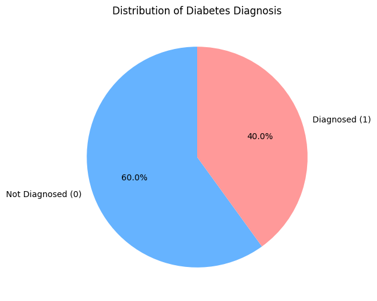

```python
import matplotlib.pyplot as plt

# Count the number of diagnosed vs. not diagnosed
diagnosis_counts = whole_data['Diagnosis'].value_counts()

# Plotting
plt.figure(figsize=(8, 6))
plt.pie(diagnosis_counts, labels=['Not Diagnosed (0)', 'Diagnosed (1)'], autopct='%1.1f%%', startangle=90, colors=['#66b3ff', '#ff9999'])
plt.title('Distribution of Diabetes Diagnosis')
plt.show()
```

It does seem like we have more people who are not diagnosed to have diabetes, however the percentages seem a bit fishy

We will pay closer attention to the causes/things which are related to the diagnosis of diabetes, which we know of from our **DU** and the categorical values which we have

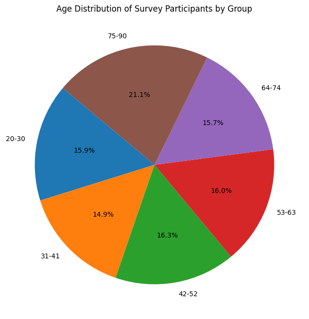

```python
import pandas as pd
import matplotlib.pyplot as plt

# Define age bins within the range of 20 to 90
bins = [20, 31, 42, 53, 64, 75, 90]  # Adjusted to create 6 bins within the 20-90 range
labels = ['20-30', '31-41', '42-52', '53-63', '64-74', '75-90']

# Categorize ages into bins
whole_data['AgeGroup'] = pd.cut(whole_data['Age'], bins=bins, labels=labels, right=False)

# Count occurrences in each bin
age_group_counts = whole_data['AgeGroup'].value_counts(sort=False)  # sort=False to maintain the order of bins

# Plotting the pie chart
plt.figure(figsize=(10, 8))
plt.pie(age_group_counts, labels=age_group_counts.index, autopct='%1.1f%%', startangle=140)
plt.title('Age Distribution of Survey Participants by Group')
plt.show()
```

```python
whole_data.isna().sum()
```

```
PatientID                         0
Age                               0
Gender                            0
Ethnicity                         0
SocioeconomicStatus               0
EducationLevel                    0
BMI                               0
Smoking                           0
AlcoholConsumption                0
PhysicalActivity                  0
DietQuality                       0
SleepQuality                      0
FamilyHistoryDiabetes             0
GestationalDiabetes               0
PolycysticOvarySyndrome           0
PreviousPreDiabetes               0
Hypertension                      0
SystolicBP                        0
DiastolicBP                       0
FastingBloodSugar                 0
HbA1c                             0
SerumCreatinine                   0
BUNLevels                         0
CholesterolTotal                  0
CholesterolLDL                    0
CholesterolHDL                    0
CholesterolTriglycerides          0
AntihypertensiveMedications       0
Statins                           0
AntidiabeticMedications           0
FrequentUrination                 0
ExcessiveThirst                   0
UnexplainedWeightLoss             0
FatigueLevels                     0
BlurredVision                     0
SlowHealingSores                  0
TinglingHandsFeet                 0
QualityOfLifeScore                0
HeavyMetalsExposure               0
OccupationalExposureChemicals     0
WaterQuality                      0
MedicalCheckupsFrequency          0
MedicationAdherence               0
HealthLiteracy                    0
Diagnosis                         0
AgeGroup                         34
dtype: int64
```

```python
# Assuming 'whole_data' is your DataFrame
nan_agegroup_rows = whole_data[whole_data['AgeGroup'].isna()]

# Print the rows where AgeGroup is NaN
nan_agegroup_rows
```

|  | PatientID | Age | Gender | Ethnicity | SocioeconomicStatus | EducationLevel | BMI | Smoking | AlcoholConsumption | PhysicalActivity | ... | TinglingHandsFeet | QualityOfLifeScore | HeavyMetalsExposure | OccupationalExposureChemicals | WaterQuality | MedicalCheckupsFrequency | MedicationAdherence | HealthLiteracy | Diagnosis | AgeGroup |
| --- | --- | --- | --- | --- | --- | --- | --- | --- | --- | --- | --- | --- | --- | --- | --- | --- | --- | --- | --- | --- | --- |
| 19 | 6019 | 90 | 0 | 0 | 0 | 2 | 35.853330 | 0 | 4.422626 | 7.429686 | ... | 1 | 11.734922 | 0 | 0 | 0 | 2.416942 | 2.356242 | 5.738591 | 1 | NaN |
| 76 | 6076 | 90 | 1 | 0 | 2 | 1 | 19.788610 | 0 | 13.284814 | 7.063108 | ... | 0 | 66.055832 | 0 | 0 | 0 | 3.704644 | 1.095211 | 5.524610 | 1 | NaN |
| 100 | 6100 | 90 | 0 | 2 | 1 | 0 | 36.788627 | 1 | 1.799198 | 2.564727 | ... | 0 | 78.818839 | 1 | 0 | 0 | 0.202265 | 7.754410 | 9.167593 | 1 | NaN |
| 176 | 6176 | 90 | 1 | 0 | 1 | 2 | 39.429551 | 0 | 10.286820 | 0.332014 | ... | 0 | 28.093566 | 0 | 0 | 0 | 3.485196 | 7.475298 | 5.227730 | 0 | NaN |
| 208 | 6208 | 90 | 0 | 0 | 0 | 1 | 27.289398 | 0 | 9.351907 | 6.969101 | ... | 0 | 65.315463 | 0 | 0 | 0 | 2.762174 | 7.422491 | 5.672697 | 1 | NaN |
| 231 | 6231 | 90 | 1 | 0 | 2 | 3 | 22.986589 | 1 | 2.424119 | 2.847354 | ... | 0 | 58.264281 | 0 | 0 | 1 | 3.337115 | 1.024909 | 2.080876 | 1 | NaN |
| 423 | 6423 | 90 | 1 | 2 | 1 | 0 | 35.504741 | 0 | 14.548585 | 2.224244 | ... | 0 | 10.903574 | 0 | 0 | 0 | 0.506138 | 6.440951 | 5.303896 | 1 | NaN |
| 625 | 6625 | 90 | 1 | 0 | 2 | 1 | 38.667766 | 1 | 5.248007 | 1.415017 | ... | 0 | 90.136049 | 0 | 0 | 0 | 0.624746 | 5.799004 | 8.562323 | 0 | NaN |
| 739 | 6739 | 90 | 1 | 0 | 0 | 3 | 34.632281 | 0 | 19.891408 | 1.523061 | ... | 0 | 62.855774 | 0 | 0 | 0 | 2.949448 | 9.555752 | 3.768971 | 1 | NaN |
| 757 | 6757 | 90 | 0 | 2 | 2 | 1 | 28.789565 | 0 | 6.322282 | 1.093298 | ... | 0 | 30.923075 | 0 | 0 | 0 | 1.335322 | 8.433395 | 6.669160 | 0 | NaN |
| 781 | 6781 | 90 | 0 | 0 | 2 | 2 | 17.565387 | 0 | 0.521098 | 4.067514 | ... | 0 | 31.624596 | 0 | 0 | 0 | 0.108992 | 8.356928 | 4.226183 | 1 | NaN |
| 824 | 6824 | 90 | 0 | 0 | 1 | 1 | 20.616254 | 1 | 16.565571 | 8.113700 | ... | 0 | 73.627974 | 0 | 0 | 0 | 2.295315 | 9.995656 | 0.437663 | 0 | NaN |
| 864 | 6864 | 90 | 1 | 0 | 1 | 0 | 25.329320 | 0 | 12.330842 | 7.837810 | ... | 0 | 80.522823 | 0 | 0 | 0 | 3.791500 | 1.188953 | 6.872172 | 0 | NaN |
| 878 | 6878 | 90 | 1 | 2 | 0 | 2 | 17.578457 | 1 | 8.249882 | 9.949730 | ... | 0 | 54.015109 | 0 | 0 | 0 | 2.115200 | 6.705879 | 5.624006 | 1 | NaN |
| 880 | 6880 | 90 | 1 | 1 | 0 | 1 | 20.251309 | 0 | 6.900658 | 9.230000 | ... | 1 | 56.467042 | 1 | 0 | 0 | 1.670129 | 8.624594 | 5.860464 | 0 | NaN |
| 935 | 6935 | 90 | 1 | 0 | 0 | 3 | 24.227359 | 0 | 8.795276 | 1.569386 | ... | 0 | 27.901000 | 0 | 1 | 0 | 0.936951 | 6.234725 | 5.634350 | 1 | NaN |
| 1004 | 7004 | 90 | 0 | 0 | 2 | 1 | 24.543854 | 1 | 9.586800 | 8.930462 | ... | 0 | 39.979163 | 0 | 0 | 0 | 2.796715 | 0.599124 | 9.226829 | 0 | NaN |
| 1100 | 7100 | 90 | 1 | 3 | 0 | 2 | 24.406660 | 1 | 11.429000 | 1.749059 | ... | 1 | 48.814042 | 0 | 0 | 0 | 0.541133 | 7.129572 | 4.789217 | 0 | NaN |
| 1238 | 7238 | 90 | 1 | 0 | 1 | 2 | 31.502355 | 0 | 13.631177 | 5.284440 | ... | 0 | 20.612852 | 1 | 0 | 0 | 0.583564 | 3.960315 | 8.259834 | 0 | NaN |
| 1250 | 7250 | 90 | 1 | 0 | 0 | 1 | 27.131138 | 0 | 18.352775 | 6.711902 | ... | 0 | 33.609352 | 0 | 0 | 0 | 1.013217 | 5.977883 | 3.279691 | 0 | NaN |
| 1277 | 7277 | 90 | 1 | 0 | 1 | 1 | 20.197281 | 0 | 18.571290 | 4.534173 | ... | 0 | 52.089776 | 0 | 0 | 0 | 1.365849 | 4.942342 | 2.150603 | 0 | NaN |
| 1344 | 7344 | 90 | 0 | 2 | 1 | 2 | 33.560628 | 0 | 0.042898 | 6.354290 | ... | 0 | 4.691115 | 0 | 1 | 0 | 1.291807 | 6.152127 | 8.620535 | 0 | NaN |
| 1361 | 7361 | 90 | 0 | 0 | 2 | 1 | 23.272226 | 0 | 10.152770 | 3.155959 | ... | 0 | 35.741340 | 0 | 0 | 0 | 0.832385 | 3.057938 | 6.655479 | 0 | NaN |
| 1388 | 7388 | 90 | 1 | 0 | 0 | 2 | 30.828758 | 0 | 5.916488 | 0.028360 | ... | 0 | 91.785393 | 0 | 0 | 0 | 0.551892 | 6.132315 | 5.335055 | 1 | NaN |
| 1429 | 7429 | 90 | 0 | 0 | 1 | 1 | 17.272423 | 0 | 15.787664 | 6.845006 | ... | 0 | 15.918778 | 0 | 0 | 0 | 1.536060 | 4.270821 | 3.741185 | 1 | NaN |
| 1462 | 7462 | 90 | 0 | 1 | 1 | 2 | 15.818562 | 0 | 6.028513 | 4.618570 | ... | 0 | 19.137196 | 0 | 0 | 0 | 1.833399 | 4.186734 | 5.702821 | 1 | NaN |
| 1485 | 7485 | 90 | 0 | 1 | 1 | 2 | 35.326271 | 1 | 14.672081 | 9.207720 | ... | 0 | 71.104539 | 0 | 0 | 0 | 0.645999 | 4.463316 | 6.756107 | 0 | NaN |
| 1622 | 7622 | 90 | 1 | 3 | 0 | 1 | 22.796237 | 0 | 0.489935 | 0.559722 | ... | 0 | 38.726710 | 1 | 0 | 0 | 1.414056 | 6.141240 | 0.966926 | 1 | NaN |
| 1711 | 7711 | 90 | 1 | 0 | 2 | 2 | 29.349850 | 0 | 1.198667 | 3.318565 | ... | 0 | 51.024186 | 0 | 0 | 0 | 1.643343 | 2.112328 | 0.984699 | 1 | NaN |
| 1731 | 7731 | 90 | 0 | 1 | 2 | 2 | 34.481752 | 0 | 14.464509 | 0.278475 | ... | 0 | 51.688954 | 0 | 0 | 0 | 3.989696 | 9.195806 | 0.617857 | 0 | NaN |
| 1776 | 7776 | 90 | 0 | 3 | 1 | 2 | 28.939864 | 0 | 7.174979 | 1.717426 | ... | 0 | 43.648495 | 0 | 0 | 0 | 1.659539 | 5.589947 | 9.189286 | 0 | NaN |
| 1804 | 7804 | 90 | 1 | 0 | 1 | 3 | 21.194713 | 0 | 5.334513 | 4.424541 | ... | 0 | 25.046039 | 0 | 0 | 0 | 1.217435 | 5.895902 | 1.106113 | 0 | NaN |
| 1842 | 7842 | 90 | 1 | 3 | 0 | 2 | 36.297507 | 0 | 2.952936 | 4.974607 | ... | 0 | 21.122955 | 0 | 0 | 0 | 2.371718 | 1.568555 | 6.664252 | 1 | NaN |
| 1865 | 7865 | 90 | 1 | 0 | 2 | 1 | 17.216809 | 0 | 10.723055 | 3.037155 | ... | 0 | 36.020193 | 0 | 1 | 0 | 1.612715 | 1.607337 | 3.725236 | 0 | NaN |

34 rows × 46 columns

Let's see what does it look like with the people who are diagnosed and the ones who are not diagnosed

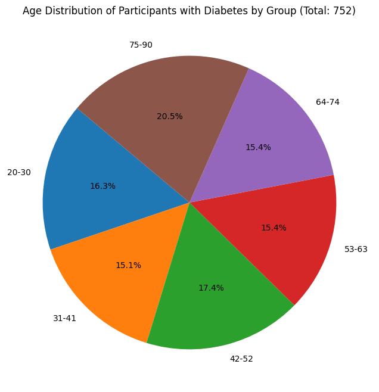

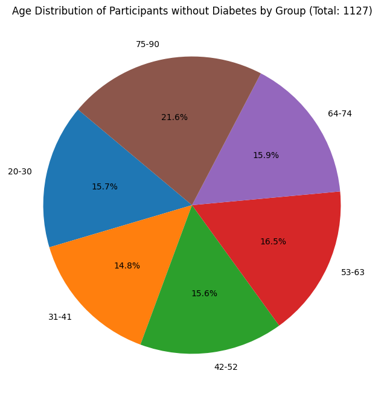

```python
# Filter the dataset into two groups
diabetes_data = whole_data[whole_data['Diagnosis'] == 1]
no_diabetes_data = whole_data[whole_data['Diagnosis'] == 0]

# Count occurrences in each bin for people with diabetes
age_group_counts_diabetes = diabetes_data['AgeGroup'].value_counts(sort=False)

# Count occurrences in each bin for people without diabetes
age_group_counts_no_diabetes = no_diabetes_data['AgeGroup'].value_counts(sort=False)

# Calculate total number of people with and without diabetes
total_with_diabetes = diabetes_data.shape[0]
total_without_diabetes = no_diabetes_data.shape[0]

# Plotting the pie chart for people with diabetes
plt.figure(figsize=(10, 8))
plt.pie(age_group_counts_diabetes, labels=age_group_counts_diabetes.index, autopct='%1.1f%%', startangle=140)
plt.title(f'Age Distribution of Participants with Diabetes by Group (Total: {total_with_diabetes})')
plt.show()

# Plotting the pie chart for people without diabetes
plt.figure(figsize=(10, 8))
plt.pie(age_group_counts_no_diabetes, labels=age_group_counts_no_diabetes.index, autopct='%1.1f%%', startangle=140)
plt.title(f'Age Distribution of Participants without Diabetes by Group (Total: {total_without_diabetes})')
plt.show()
```

Once again, quite even, despite the fact that there is a difference in the amount of data which we are working with

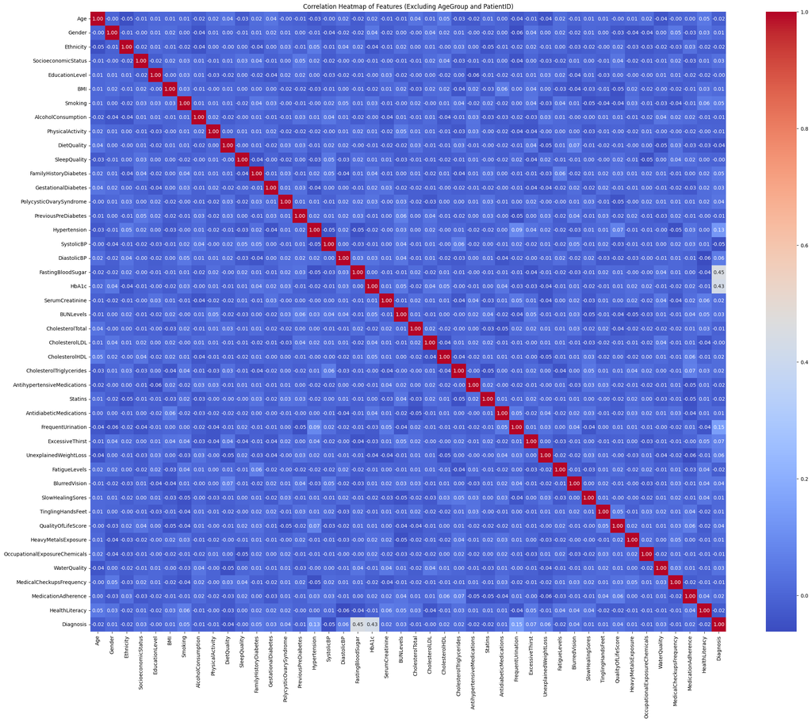

```python
# Drop 'AgeGroup' and 'PatientID' columns from the DataFrame
whole_data_modified = whole_data.drop(['AgeGroup', 'PatientID'], axis=1)

# Calculate the correlation matrix for the modified DataFrame
corr_matrix = whole_data_modified.corr()

# Plotting the heatmap
plt.figure(figsize=(28, 22))
sns.heatmap(corr_matrix, annot=True, fmt=".2f", cmap='coolwarm', cbar=True)
plt.title('Correlation Heatmap of Features (Excluding AgeGroup and PatientID)')
plt.show()
```

It would be a good idea to focus our attention to the Diagnosis row. Let us focus our attention and the possible, higher factor linear correlation features such as `Smoking`,`FamilyHistoryDiabetes`,`DiastolicBP`,`Hypertension`,`FastingBloodSugar`,`HbA1c`,`FrequentUrination`,`ExcessiveThirst`,`UnexplainedWeightLoss`. It is good to keep them in mind since they do overlap with our domain understanding.

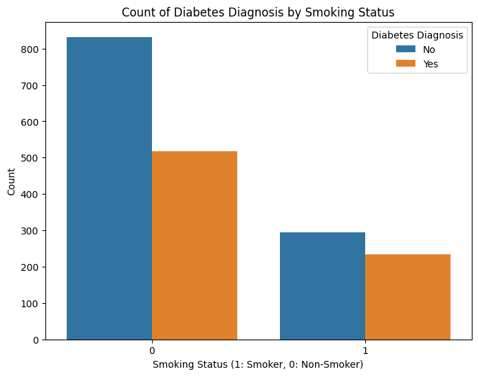

```python
# Create a bar plot
plt.figure(figsize=(8, 6))
sns.countplot(x='Smoking', hue='Diagnosis', data=whole_data)

plt.title('Count of Diabetes Diagnosis by Smoking Status')
plt.xlabel('Smoking Status (1: Smoker, 0: Non-Smoker)')
plt.ylabel('Count')
plt.legend(title='Diabetes Diagnosis', labels=['No', 'Yes'])

plt.show()
```

We do have more cases of people who were not smokers, however, the patients who were diagnosed with the illness do seem to be more even, which is something to take into consideration. That does give us the impression that the smokers somehow are more succeptable to developing diabetes. Let us get a better visualization of that

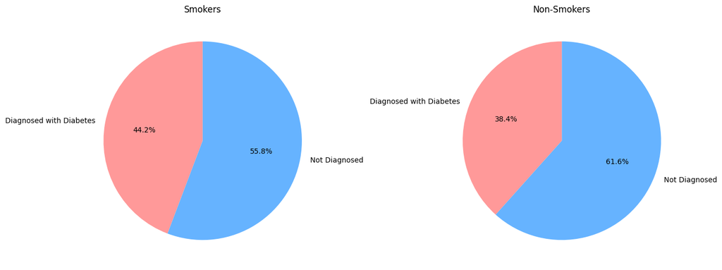

```python
# Calculate percentages
smokers_diagnosed_percentage = whole_data[whole_data['Smoking'] == 1]['Diagnosis'].mean() * 100
non_smokers_diagnosed_percentage = whole_data[whole_data['Smoking'] == 0]['Diagnosis'].mean() * 100

# Plotting
fig, axs = plt.subplots(1, 2, figsize=(14, 7))

# Pie chart for smokers
axs[0].pie([smokers_diagnosed_percentage, 100 - smokers_diagnosed_percentage], labels=['Diagnosed with Diabetes', 'Not Diagnosed'], autopct='%1.1f%%', startangle=90, colors=['#ff9999','#66b3ff'])
axs[0].set_title('Smokers')

# Pie chart for non-smokers
axs[1].pie([non_smokers_diagnosed_percentage, 100 - non_smokers_diagnosed_percentage], labels=['Diagnosed with Diabetes', 'Not Diagnosed'], autopct='%1.1f%%', startangle=90, colors=['#ff9999','#66b3ff'])
axs[1].set_title('Non-Smokers')

plt.tight_layout()
plt.show()
```

As suspected, smokers do seem to have a higher correlation with the possible diagnosis and development of diabetes

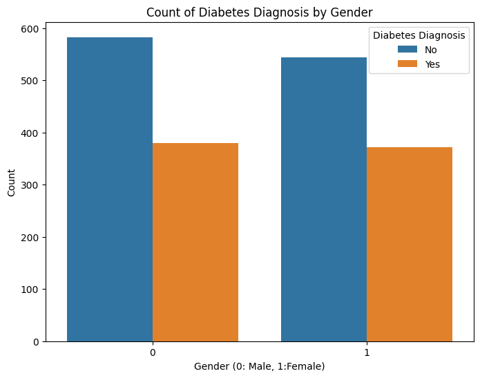

```python
# Create a bar plot
plt.figure(figsize=(8, 6))
sns.countplot(x='Gender', hue='Diagnosis', data=whole_data)

plt.title('Count of Diabetes Diagnosis by Gender')
plt.xlabel('Gender (0: Male, 1:Female)')
plt.ylabel('Count')
plt.legend(title='Diabetes Diagnosis', labels=['No', 'Yes'])

plt.show()
```

It is equivelent among the genders as well

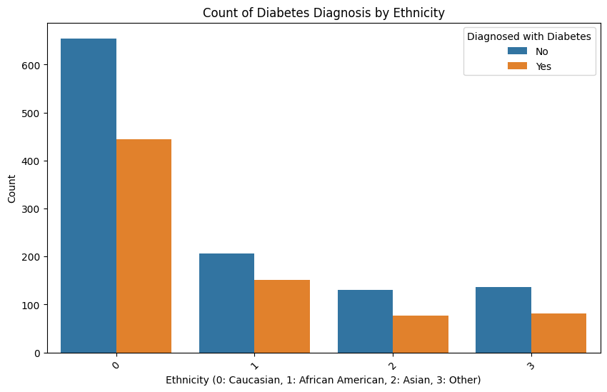

```python
# Create a bar plot
plt.figure(figsize=(10, 6))
sns.countplot(x='Ethnicity', hue='Diagnosis', data=whole_data)

plt.title('Count of Diabetes Diagnosis by Ethnicity')
plt.xlabel('Ethnicity (0: Caucasian, 1: African American, 2: Asian, 3: Other)')
plt.ylabel('Count')
plt.legend(title='Diagnosed with Diabetes', labels=['No', 'Yes'])

plt.xticks(rotation=45)  # Rotate labels to avoid overlap if necessary

plt.show()
```

https://www.mayoclinic.org/diseases-conditions/diabetes/symptoms-causes/syc-20371444

```
" ...Race or ethnicity also may raise your risk
of developing type 2 diabetes. Although it's unclear why,
certain people — including Black, Hispanic, American Indian
and Asian American people — are at higher risk..."
```

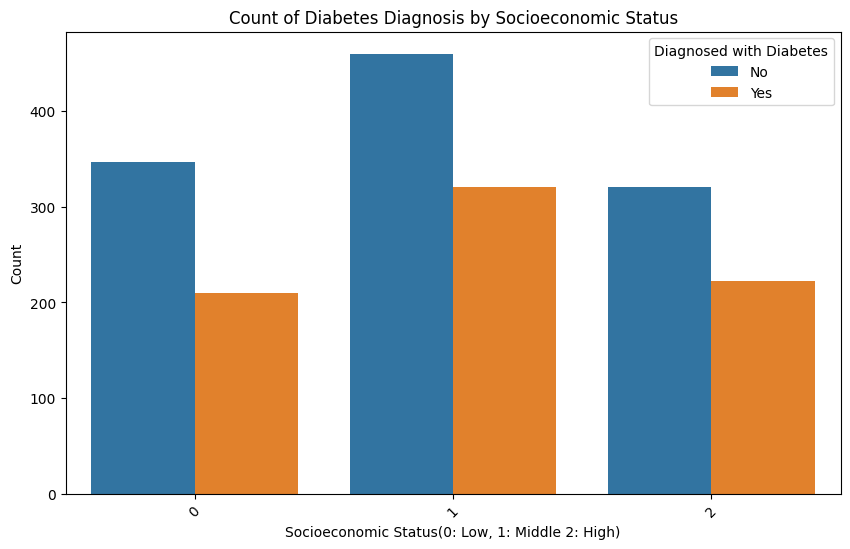

```python
# Create a bar plot
plt.figure(figsize=(10, 6))
sns.countplot(x='SocioeconomicStatus', hue='Diagnosis', data=whole_data)

plt.title('Count of Diabetes Diagnosis by Socioeconomic Status')
plt.xlabel('Socioeconomic Status(0: Low, 1: Middle 2: High)')
plt.ylabel('Count')
plt.legend(title='Diagnosed with Diabetes', labels=['No', 'Yes'])

plt.xticks(rotation=45)  # Rotate labels to avoid overlap if necessary

plt.show()
```

Let us see more about the distribution, becuase I am curios. It was documented that people of low and middle socioeconomic status are likely to develop diabetes, but it seems a little bit even here

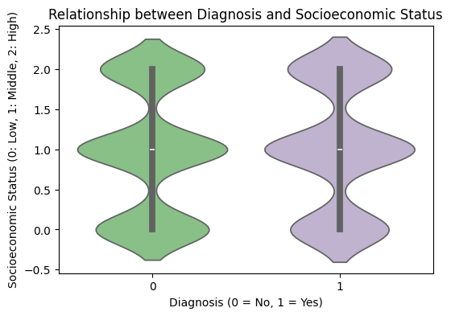

```python
import warnings
warnings.filterwarnings("ignore", category=FutureWarning)  # Suppress specific FutureWarning

plt.figure(figsize=(6, 4))

# Violin Plot Between Diagnosis and Socioeconomic Status
sns.violinplot(data=whole_data, x='Diagnosis', y='SocioeconomicStatus', palette='Accent')
plt.title('Relationship between Diagnosis and Socioeconomic Status')
plt.xlabel('Diagnosis (0 = No, 1 = Yes)')
plt.ylabel('Socioeconomic Status (0: Low, 1: Middle, 2: High)')
```

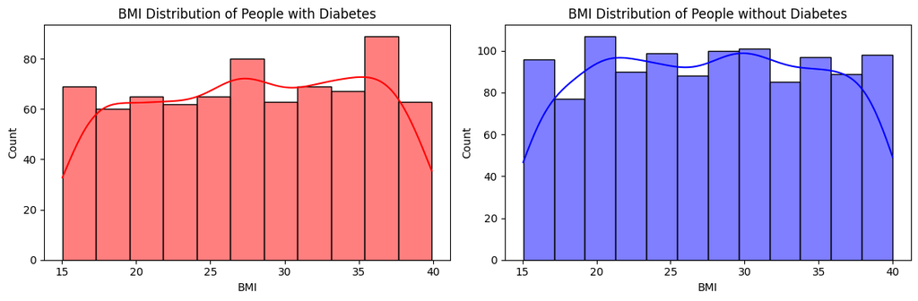

```python
plt.figure(figsize=(12, 4))

# Histogram Plot for BMI of People Diagnosed with Diabetes
plt.subplot(1, 2, 1)  # 1 row, 2 columns, 1st subplot
sns.histplot(data=whole_data[whole_data['Diagnosis'] == 1], x='BMI', color='red', kde=True)
plt.title('BMI Distribution of People with Diabetes')
plt.xlabel('BMI')
plt.ylabel('Count')

# Histogram Plot for BMI of People Not Diagnosed with Diabetes
plt.subplot(1, 2, 2)  # 1 row, 2 columns, 2nd subplot
sns.histplot(data=whole_data[whole_data['Diagnosis'] == 0], x='BMI', color='blue', kde=True)
plt.title('BMI Distribution of People without Diabetes')
plt.xlabel('BMI')
plt.ylabel('Count')

plt.tight_layout()
```

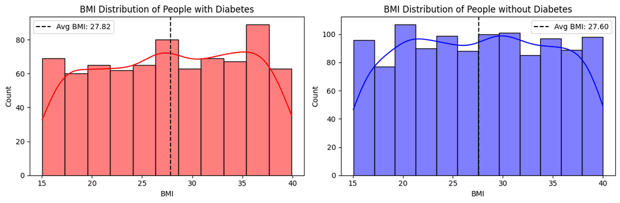

```python
plt.figure(figsize=(12, 4))

# Calculate average BMI for people with and without diabetes
avg_bmi_diabetes = whole_data[whole_data['Diagnosis'] == 1]['BMI'].mean()
avg_bmi_no_diabetes = whole_data[whole_data['Diagnosis'] == 0]['BMI'].mean()

# Histogram Plot for BMI of People Diagnosed with Diabetes
plt.subplot(1, 2, 1)  # 1 row, 2 columns, 1st subplot
sns.histplot(data=whole_data[whole_data['Diagnosis'] == 1], x='BMI', color='red', kde=True)
plt.axvline(avg_bmi_diabetes, color='k', linestyle='--', label=f'Avg BMI: {avg_bmi_diabetes:.2f}')
plt.title('BMI Distribution of People with Diabetes')
plt.xlabel('BMI')
plt.ylabel('Count')
plt.legend()

# Histogram Plot for BMI of People Not Diagnosed with Diabetes
plt.subplot(1, 2, 2)  # 1 row, 2 columns, 2nd subplot
sns.histplot(data=whole_data[whole_data['Diagnosis'] == 0], x='BMI', color='blue', kde=True)
plt.axvline(avg_bmi_no_diabetes, color='k', linestyle='--', label=f'Avg BMI: {avg_bmi_no_diabetes:.2f}')
plt.title('BMI Distribution of People without Diabetes')
plt.xlabel('BMI')
plt.ylabel('Count')
plt.legend()

plt.tight_layout()
```

It is a little bit interesting to see that all of the people have similiar BMI, however, it should be noted that poeple with a higher body mass index, are more prone to developing diabetes. The results that we are shown here do raise a concern on the legitimecy of the dataset.

-https://www.honorhealth.com/medical-services/bariatric-weight-loss-surgery/patient-education-and-support/comorbidities-type-2-diabetes

```
"What you consume throughout your day and how active you are affects your risk of developing type 2 diabetes. Being overweight (BMI of 25-29.9), or affected by obesity (BMI of 30-39.9) or morbid obesity (BMI of 40 or greater), greatly increases your risk of developing type 2 diabetes. The more excess weight you have, the more resistant your muscle and tissue cells become to your own insulin hormone. More than 90% of people with type 2 diabetes are overweight or affected by a degree of obesity."
```

Let us continue with another one of the considered major factors:

If somebody in the family previously had it

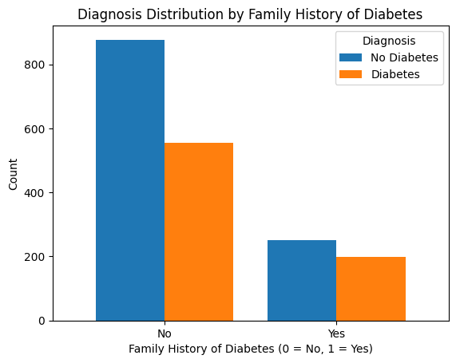

```python
grouped_data = whole_data.groupby(['FamilyHistoryDiabetes', 'Diagnosis']).size().unstack()

# Plotting the bar charts side by side
ax = grouped_data.plot(kind='bar', width=0.8)
plt.title('Diagnosis Distribution by Family History of Diabetes')
plt.xlabel('Family History of Diabetes (0 = No, 1 = Yes)')
plt.ylabel('Count')
plt.xticks(ticks=[0, 1], labels=['No', 'Yes'], rotation=0)  # Adjusting x-axis labels for clarity
plt.legend(title='Diagnosis', labels=['No Diabetes', 'Diabetes'])
plt.show()
```

I am not happy with this current way of visualising the data

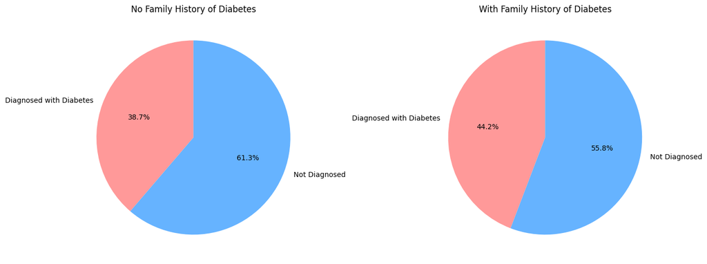

```python
import matplotlib.pyplot as plt

# Calculate the total counts for each group
total_counts = grouped_data.sum(axis=1)

# Calculate the percentage of people diagnosed with diabetes in each group
percentage_diabetes = (grouped_data[1] / total_counts) * 100  # Assuming '1' represents 'Diagnosed with Diabetes'

# Create a DataFrame with these percentages
percentage_df = percentage_diabetes.reset_index().rename(columns={1: 'Percentage with Diabetes'})


# Rename the column '0' to 'Percentage with Diabetes'
percentage_df = percentage_df.rename(columns={0: 'Percentage with Diabetes'})


# Data preparation
no_family_history_percentage = percentage_df.loc[percentage_df['FamilyHistoryDiabetes'] == 0, 'Percentage with Diabetes'].values[0]
with_family_history_percentage = percentage_df.loc[percentage_df['FamilyHistoryDiabetes'] == 1, 'Percentage with Diabetes'].values[0]

# Plotting
fig, axs = plt.subplots(1, 2, figsize=(14, 7))

# Pie chart for people without a family history of diabetes
axs[0].pie([no_family_history_percentage, 100 - no_family_history_percentage], labels=['Diagnosed with Diabetes', 'Not Diagnosed'], autopct='%1.1f%%', startangle=90, colors=['#ff9999','#66b3ff'])
axs[0].set_title('No Family History of Diabetes')

# Pie chart for people with a family history of diabetes
axs[1].pie([with_family_history_percentage, 100 - with_family_history_percentage], labels=['Diagnosed with Diabetes', 'Not Diagnosed'], autopct='%1.1f%%', startangle=90, colors=['#ff9999','#66b3ff'])
axs[1].set_title('With Family History of Diabetes')

plt.tight_layout()
plt.show()
```

It does seem to also give us quite a bump in the percentages so I would keep it in mind when creating the model. It does show in my opinion a that the fact is, the heredetery disposition plays quite a vital role

### Current Conclusion:

We will first work on a model which has the factors that were considered important in the domain understadning as well as some of the symptoms. Not only that but some of the things which our correlation matrix does seem to show, which are the the factors used for a diagnosis as well, when it comes to the selection of the features. This will include:

- BMI
- Age
- FamilyHistoryDiabetes
- Smoking

as well as (used in the medical field to diagnose diabetes):

- FastingBloodSugar
- HbA1c

# **Phase 3**

### Preprocessing and modeling

### Downsampling

The initial plan is to probably downsample the data since there are who were not diagnosed to have diabetes

```python
diabetes = whole_data[whole_data['Diagnosis'] == 1]
no_diabetes_data = whole_data[whole_data['Diagnosis'] == 0]

# Since diagnosed cases are fewer, downsample the not_diagnosed group to match the diagnosed group's size
not_diagnosed_downsampled = no_diabetes_data.sample(n=len(diabetes), random_state=42)

# Concatenate the downsampled not_diagnosed group with the diagnosed group
balanced_data_downsampled = pd.concat([diabetes, not_diagnosed_downsampled])

balanced_data_downsampled['Diagnosis'].value_counts()
```

```
Diagnosis
1    752
0    752
Name: count, dtype: int64
```

### Upsampling

```python
from imblearn.over_sampling import SMOTE
from sklearn.model_selection import train_test_split
import pandas as pd


# Separate features and target variable
# target = 'Diagnosis'
X = whole_data.drop(['Diagnosis','AgeGroup'], axis=1)
y = whole_data['Diagnosis']

# Apply SMOTE
smote = SMOTE(random_state=42)
X_resampled, y_resampled = smote.fit_resample(X, y)

# Combine the resampled features and target into a single DataFrame
balanced_data_smote = pd.concat([pd.DataFrame(X_resampled), pd.DataFrame(y_resampled, columns=['Diagnosis'])], axis=1)

# Display the new value counts
print(balanced_data_smote['Diagnosis'].value_counts())
```

```
Diagnosis
1    1127
0    1127
Name: count, dtype: int64
```

Now that the data is of equal size, it will be better for training and testing the model, giving it an easier way to distinguish the the wanted results with the features that we want

## Gradient Boosting Classifier

The reason for using GBC is because it is a powerfull model, which is good for classification. We will try the differenct training and testing spilts as well with the 2 training sets we just created.

### This is the 80/20 - train/test split with the downsampled dataset

```python
from sklearn.model_selection import train_test_split
from sklearn.ensemble import GradientBoostingClassifier
from sklearn.metrics import accuracy_score

# Prepare the data from 'balanced_data'
features = ['BMI', 'Age', 'FamilyHistoryDiabetes', 'Smoking', 'FastingBloodSugar', 'HbA1c']
X = balanced_data_downsampled[features]
y = balanced_data_downsampled['Diagnosis']

# Split the data into training and testing sets
X_train, X_test, y_train, y_test = train_test_split(X, y, test_size=0.2, random_state=42)

# Create the Gradient Boosting model
gb_model = GradientBoostingClassifier(n_estimators=100, learning_rate=0.1, max_depth=3, random_state=42)

# Train the model
gb_model.fit(X_train, y_train)

# Predict on the test set
y_pred = gb_model.predict(X_test)

# Evaluate the model
accuracy = accuracy_score(y_test, y_pred)
print(f"Model Accuracy: {accuracy}")
```

```
Model Accuracy: 0.8637873754152824
```

##### Evaluation - Confusion Matrix, Feature imporance and classification report

#### **Confusion matrix**

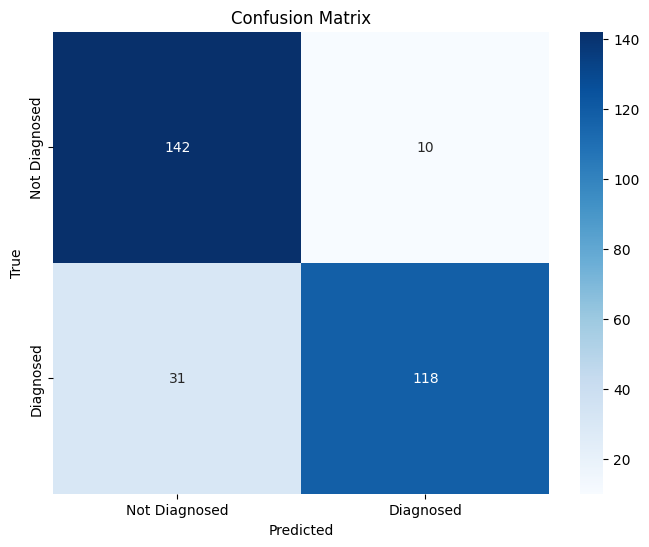

```
The amount of correctly predicted individuals, who did not have the condition (True negative): 142
The amount of correctly predicted individuals, who did have the condition (True positive): 118
The amount of incorrectly predicted individuals, predicted to have the condition, but actually did not (False positive): 10
The amount of incorrectly predicted individuals, predicted to  not have the condition, but actually did (False negative): 31
```

```python
from sklearn.metrics import confusion_matrix
import seaborn as sns
import matplotlib.pyplot as plt

# Generate the confusion matrix
cm = confusion_matrix(y_test, y_pred)

# Visualize the confusion matrix
plt.figure(figsize=(8, 6))
sns.heatmap(cm, annot=True, fmt="d", cmap="Blues", xticklabels=['Not Diagnosed', 'Diagnosed'], yticklabels=['Not Diagnosed', 'Diagnosed'])
plt.xlabel('Predicted')
plt.ylabel('True')
plt.title('Confusion Matrix')
plt.show()

tn, fp, fn, tp = cm.ravel()
print(f"The amount of correctly predicted individuals, who did not have the condition (True negative): {tn}")
print(f"The amount of correctly predicted individuals, who did have the condition (True positive): {tp}")
print(f"The amount of incorrectly predicted individuals, predicted to have the condition, but actually did not (False positive): {fp}")
print(f"The amount of incorrectly predicted individuals, predicted to  not have the condition, but actually did (False negative): {fn}")
```

#### **Feature importance**

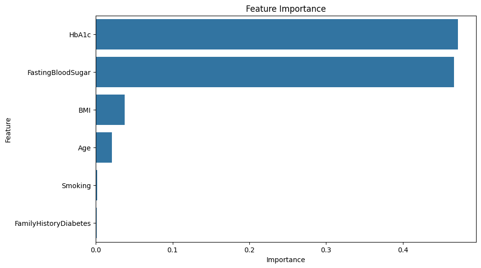

```python
import pandas as pd

# Extract feature importance
feature_importance = gb_model.feature_importances_

# Create a DataFrame for visualization
features_df = pd.DataFrame({'Feature': features, 'Importance': feature_importance})

# Sort the DataFrame based on importance
features_df = features_df.sort_values(by='Importance', ascending=False)

# Visualize feature importance
plt.figure(figsize=(10, 6))
sns.barplot(x='Importance', y='Feature', data=features_df)
plt.title('Feature Importance')
plt.xlabel('Importance')
plt.ylabel('Feature')
plt.show()
```

#### **Classification report**

```python
from sklearn.metrics import classification_report

# Generate the classification report
report = classification_report(y_test, y_pred, target_names=['Not Diagnosed', 'Diagnosed'])

print(report)
```

```
               precision    recall  f1-score   support

Not Diagnosed       0.82      0.93      0.87       152
    Diagnosed       0.92      0.79      0.85       149

     accuracy                           0.86       301
    macro avg       0.87      0.86      0.86       301
 weighted avg       0.87      0.86      0.86       301
```

### This is the 70/30 - train/test split with the downsampled dataset

```python
from sklearn.model_selection import train_test_split
from sklearn.ensemble import GradientBoostingClassifier
from sklearn.metrics import accuracy_score

# Prepare the data from 'balanced_data'
features = ['BMI', 'Age', 'FamilyHistoryDiabetes', 'Smoking', 'FastingBloodSugar', 'HbA1c']
X = balanced_data_downsampled[features]
y = balanced_data_downsampled['Diagnosis']

# Split the data into training and testing sets
X_train, X_test, y_train, y_test = train_test_split(X, y, test_size=0.3, random_state=42)

# Create the Gradient Boosting model
gb_model = GradientBoostingClassifier(n_estimators=100, learning_rate=0.1, max_depth=3, random_state=42)

# Train the model
gb_model.fit(X_train, y_train)

# Predict on the test set
y_pred = gb_model.predict(X_test)

# Evaluate the model
accuracy = accuracy_score(y_test, y_pred)
print(f"Model Accuracy: {accuracy}")
```

```
Model Accuracy: 0.8716814159292036
```

#### **Confusion matrix**

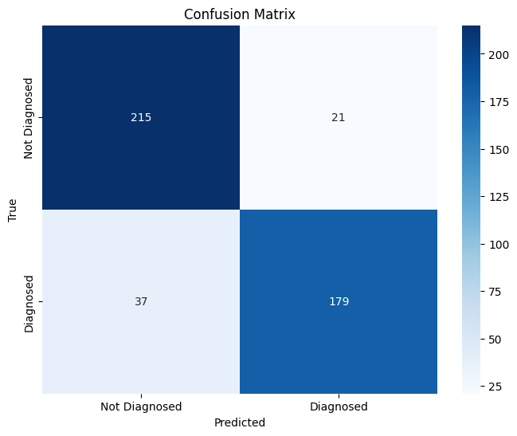

```
The amount of correctly predicted individuals, who did not have the condition (True negative): 215
The amount of correctly predicted individuals, who did have the condition (True positive): 179
The amount of incorrectly predicted individuals, predicted to have the condition, but actually did not (False positive): 21
The amount of incorrectly predicted individuals, predicted to  not have the condition, but actually did (False negative): 37
```

```python
from sklearn.metrics import confusion_matrix
import seaborn as sns
import matplotlib.pyplot as plt

# Generate the confusion matrix
cm = confusion_matrix(y_test, y_pred)

# Visualize the confusion matrix
plt.figure(figsize=(8, 6))
sns.heatmap(cm, annot=True, fmt="d", cmap="Blues", xticklabels=['Not Diagnosed', 'Diagnosed'], yticklabels=['Not Diagnosed', 'Diagnosed'])
plt.xlabel('Predicted')
plt.ylabel('True')
plt.title('Confusion Matrix')
plt.show()

tn, fp, fn, tp = cm.ravel()
print(f"The amount of correctly predicted individuals, who did not have the condition (True negative): {tn}")
print(f"The amount of correctly predicted individuals, who did have the condition (True positive): {tp}")
print(f"The amount of incorrectly predicted individuals, predicted to have the condition, but actually did not (False positive): {fp}")
print(f"The amount of incorrectly predicted individuals, predicted to  not have the condition, but actually did (False negative): {fn}")
```

#### **Feature importance**

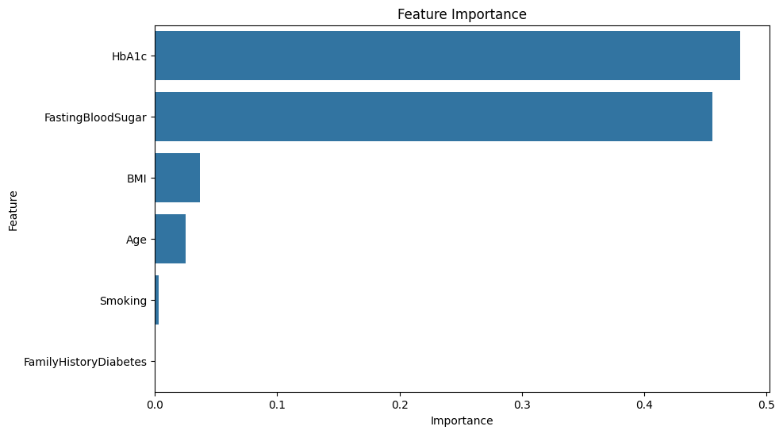

```python
import pandas as pd

# Extract feature importance
feature_importance = gb_model.feature_importances_

# Create a DataFrame for visualization
features_df = pd.DataFrame({'Feature': features, 'Importance': feature_importance})

# Sort the DataFrame based on importance
features_df = features_df.sort_values(by='Importance', ascending=False)

# Visualize feature importance
plt.figure(figsize=(10, 6))
sns.barplot(x='Importance', y='Feature', data=features_df)
plt.title('Feature Importance')
plt.xlabel('Importance')
plt.ylabel('Feature')
plt.show()
```

#### **Classification report**

```python
from sklearn.metrics import classification_report

# Generate the classification report
report = classification_report(y_test, y_pred, target_names=['Not Diagnosed', 'Diagnosed'])

print(report)
```

```
               precision    recall  f1-score   support

Not Diagnosed       0.85      0.91      0.88       236
    Diagnosed       0.90      0.83      0.86       216

     accuracy                           0.87       452
    macro avg       0.87      0.87      0.87       452
 weighted avg       0.87      0.87      0.87       452
```

### Training and Testing - Gradient Boosting Classifier - 2

### This is the 80/20 - train/test split with the upsampled dataset

```python
from sklearn.model_selection import train_test_split
from sklearn.ensemble import GradientBoostingClassifier
from sklearn.metrics import accuracy_score

# Prepare the data from 'balanced_data'
features = ['BMI', 'Age', 'FamilyHistoryDiabetes', 'Smoking', 'FastingBloodSugar', 'HbA1c']
X = balanced_data_smote[features]
y = balanced_data_smote['Diagnosis']

# Split the data into training and testing sets
X_train, X_test, y_train, y_test = train_test_split(X, y, test_size=0.2, random_state=42)

# Create the Gradient Boosting model
gb_model = GradientBoostingClassifier(n_estimators=100, learning_rate=0.1, max_depth=3, random_state=42)

# Train the model
gb_model.fit(X_train, y_train)

# Predict on the test set
y_pred = gb_model.predict(X_test)

# Evaluate the model
accuracy = accuracy_score(y_test, y_pred)
print(f"Model Accuracy: {accuracy}")
```

```
Model Accuracy: 0.8913525498891353
```

#### **Confusion matrix**

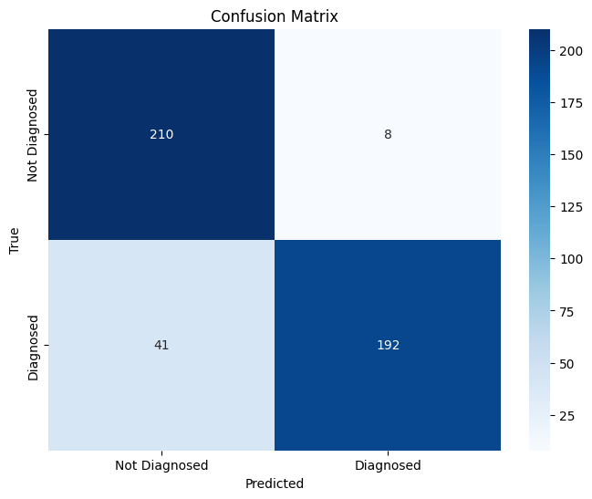

```
The amount of correctly predicted individuals, who did not have the condition (True negative): 210
The amount of correctly predicted individuals, who did have the condition (True positive): 192
The amount of incorrectly predicted individuals, predicted to have the condition, but actually did not (False positive): 8
The amount of incorrectly predicted individuals, predicted to  not have the condition, but actually did (False negative): 41
```

```python
from sklearn.metrics import confusion_matrix
import seaborn as sns
import matplotlib.pyplot as plt

# Generate the confusion matrix
cm = confusion_matrix(y_test, y_pred)

# Visualize the confusion matrix
plt.figure(figsize=(8, 6))
sns.heatmap(cm, annot=True, fmt="d", cmap="Blues", xticklabels=['Not Diagnosed', 'Diagnosed'], yticklabels=['Not Diagnosed', 'Diagnosed'])
plt.xlabel('Predicted')
plt.ylabel('True')
plt.title('Confusion Matrix')
plt.show()

tn, fp, fn, tp = cm.ravel()
print(f"The amount of correctly predicted individuals, who did not have the condition (True negative): {tn}")
print(f"The amount of correctly predicted individuals, who did have the condition (True positive): {tp}")
print(f"The amount of incorrectly predicted individuals, predicted to have the condition, but actually did not (False positive): {fp}")
print(f"The amount of incorrectly predicted individuals, predicted to  not have the condition, but actually did (False negative): {fn}")
```

#### **Feature importance**

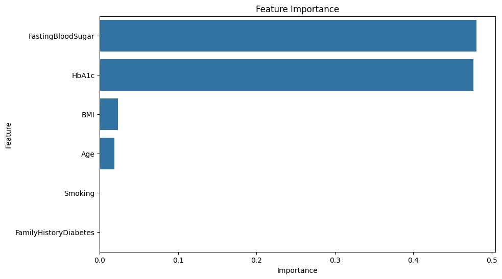

```python
import pandas as pd

# Extract feature importance
feature_importance = gb_model.feature_importances_

# Create a DataFrame for visualization
features_df = pd.DataFrame({'Feature': features, 'Importance': feature_importance})

# Sort the DataFrame based on importance
features_df = features_df.sort_values(by='Importance', ascending=False)

# Visualize feature importance
plt.figure(figsize=(10, 6))
sns.barplot(x='Importance', y='Feature', data=features_df)
plt.title('Feature Importance')
plt.xlabel('Importance')
plt.ylabel('Feature')
plt.show()
```

#### **Classification report**

```python
from sklearn.metrics import classification_report

# Generate the classification report
report = classification_report(y_test, y_pred, target_names=['Not Diagnosed', 'Diagnosed'])

print(report)
```

```
               precision    recall  f1-score   support

Not Diagnosed       0.84      0.96      0.90       218
    Diagnosed       0.96      0.82      0.89       233

     accuracy                           0.89       451
    macro avg       0.90      0.89      0.89       451
 weighted avg       0.90      0.89      0.89       451
```

### This is the 70/30 - train/test split with the upsampled dataset

```python
from sklearn.model_selection import train_test_split
from sklearn.ensemble import GradientBoostingClassifier
from sklearn.metrics import accuracy_score

# Prepare the data from 'balanced_data'
features = ['BMI', 'Age', 'FamilyHistoryDiabetes', 'Smoking', 'FastingBloodSugar', 'HbA1c']
X = balanced_data_smote[features]
y = balanced_data_smote['Diagnosis']

# Split the data into training and testing sets
X_train, X_test, y_train, y_test = train_test_split(X, y, test_size=0.3, random_state=42)

# Create the Gradient Boosting model
gb_model = GradientBoostingClassifier(n_estimators=100, learning_rate=0.1, max_depth=3, random_state=42)

# Train the model
gb_model.fit(X_train, y_train)

# Predict on the test set
y_pred = gb_model.predict(X_test)

# Evaluate the model
accuracy = accuracy_score(y_test, y_pred)
print(f"Model Accuracy: {accuracy}")
```

```
Model Accuracy: 0.8759231905465288
```

#### **Confusion matrix**

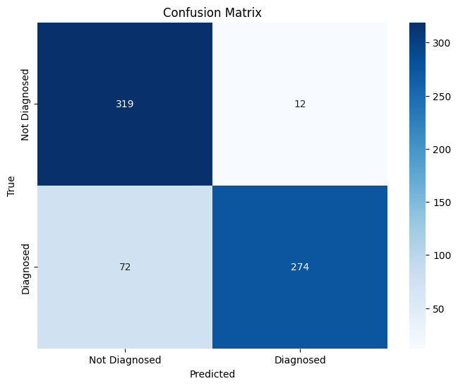

```
The amount of correctly predicted individuals, who did not have the condition (True negative): 319
The amount of correctly predicted individuals, who did have the condition (True positive): 274
The amount of incorrectly predicted individuals, predicted to have the condition, but actually did not (False positive): 12
The amount of incorrectly predicted individuals, predicted to  not have the condition, but actually did (False negative): 72
```

```python
from sklearn.metrics import confusion_matrix
import seaborn as sns
import matplotlib.pyplot as plt

# Generate the confusion matrix
cm = confusion_matrix(y_test, y_pred)

# Visualize the confusion matrix
plt.figure(figsize=(8, 6))
sns.heatmap(cm, annot=True, fmt="d", cmap="Blues", xticklabels=['Not Diagnosed', 'Diagnosed'], yticklabels=['Not Diagnosed', 'Diagnosed'])
plt.xlabel('Predicted')
plt.ylabel('True')
plt.title('Confusion Matrix')
plt.show()

tn, fp, fn, tp = cm.ravel()
print(f"The amount of correctly predicted individuals, who did not have the condition (True negative): {tn}")
print(f"The amount of correctly predicted individuals, who did have the condition (True positive): {tp}")
print(f"The amount of incorrectly predicted individuals, predicted to have the condition, but actually did not (False positive): {fp}")
print(f"The amount of incorrectly predicted individuals, predicted to  not have the condition, but actually did (False negative): {fn}")
```

#### **Feature importance**

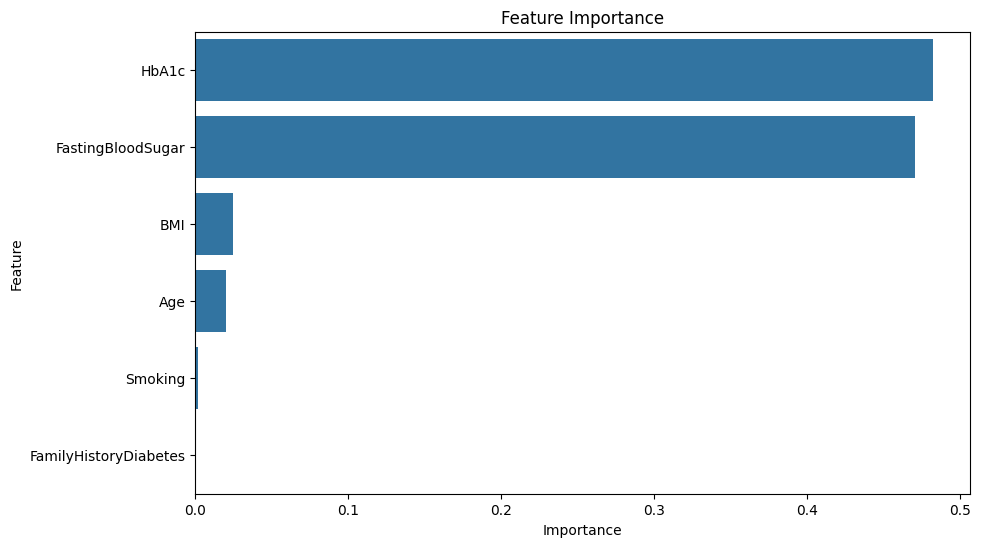

```python
import pandas as pd

# Extract feature importance
feature_importance = gb_model.feature_importances_

# Create a DataFrame for visualization
features_df = pd.DataFrame({'Feature': features, 'Importance': feature_importance})

# Sort the DataFrame based on importance
features_df = features_df.sort_values(by='Importance', ascending=False)

# Visualize feature importance
plt.figure(figsize=(10, 6))
sns.barplot(x='Importance', y='Feature', data=features_df)
plt.title('Feature Importance')
plt.xlabel('Importance')
plt.ylabel('Feature')
plt.show()
```

#### **Classification report**

```python
from sklearn.metrics import classification_report

# Generate the classification report
report = classification_report(y_test, y_pred, target_names=['Not Diagnosed', 'Diagnosed'])

print(report)
```

```
               precision    recall  f1-score   support

Not Diagnosed       0.82      0.96      0.88       331
    Diagnosed       0.96      0.79      0.87       346

     accuracy                           0.88       677
    macro avg       0.89      0.88      0.88       677
 weighted avg       0.89      0.88      0.88       677
```

### Conclusion: GBM

It seems that the model with the highest accuracy is `The 80/20 - train/test split with the upsampled dataset`,being 89% at the time of writing this conclusion. It is understandable that the features which are having the most importance on the model are the `FastingBloodSugar` and `HbA1c`, since they are the ones which are used in the medical field. The classification report also shows that model is perfoming quite well.

## Deep neural networks

After a discussion with the machine learning teacher before the beggining of the project it was recommended for me to try out and make a research on `deep neural networks`

To get a better idea of what we are working with first we have to look into the core of the suggestion - **What are deep neural netwroks?**

#### What is a DNN?

A Deep Neural Network (DNN) is a type of artificial neural network characterized by its multiple layers, which lie between the input and output layers. Neural networks, regardless of their specific architecture, share common elements including neurons, synapses, weights, biases, and activation functions. Collectively, these components enable the network to perform complex computations in a manner reminiscent of the human brain's functionality. DNNs, like other machine learning algorithms, can be trained to improve their performance on given tasks.

Deep Neural Networks (DNNs) are generally structured as feedforward networks, where information moves in a single direction from the input layer to the output layer without any backward loops. Initially, a DNN constructs a network of virtual neurons and assigns initial random values, known as "weights," to the connections between these neurons. These weights are then used in calculations with the inputs to produce outputs, typically ranging from 0 to 1. If the network fails to accurately identify a specific pattern, it employs an algorithm to adjust the weights. This adjustment process allows the network to modify the influence of certain parameters progressively, enabling it to identify the correct computational operations needed to effectively process the input data.

What kinds of DNN are there and where are they used?

There are 3 different kinds of DNN:

- Recurrent Neural Networks (RNNs), which allow data to flow in multiple directions, are employed in tasks like language modeling. Long Short-Term Memory (LSTM) networks are especially suited for these applications due to their ability to remember information for long periods.
- Convolutional Neural Networks (CNNs) are primarily utilized in the field of computer vision. Additionally, CNNs have found applications in a coustic modeling, which is a critical component of Automatic Speech Recognition (ASR) systems.
- Multilayer Perceptron/Multilayer Fast forward neural network (MLP/MLFFNN) refers to a contemporary type of feedforward artificial neural network. It features fully connected neurons that utilize a nonlinear activation function. Structured in a minimum of three layers, MLPs are distinguished by their capability to classify data that cannot be separated linearly. They were created to fix the issue of the small amounts of hidden layers used for training and making more of them, so that the models work better

### MLFFNN/MLP - 80/20 split with downsampled data

```python
# Import necessary libraries
import pandas as pd
from sklearn.model_selection import train_test_split
from sklearn.preprocessing import StandardScaler
from tensorflow.keras.models import Sequential
from tensorflow.keras.layers import Dense

X = balanced_data_downsampled.drop(['Diagnosis', 'AgeGroup'], axis=1)  # Features
y = balanced_data_downsampled['Diagnosis']  # Target variable

# Normalise the Data
scaler = StandardScaler()
X_scaled = scaler.fit_transform(X)

# Split into Training and Test Sets
X_train, X_test, y_train, y_test = train_test_split(X_scaled, y, test_size=0.2, random_state=42)

# Build the Neural Network Model
model = Sequential([
    Dense(16, activation='relu', input_shape=(X_train.shape[1],)),
    Dense(32, activation='relu'),  # Added layer with 32 neurons
    Dense(64, activation='relu'),  # Added layer with 64 neurons
    Dense(32, activation='relu'),  # Added another layer with 32 neurons
    Dense(16, activation='relu'),  # Original layer
    Dense(1, activation='sigmoid')
])

# Compile the Model
model.compile(optimizer='adam', loss='binary_crossentropy', metrics=['accuracy'])

# Train the Model
model.fit(X_train, y_train, epochs=150, validation_split=0.2)

# Evaluate the Model
loss, accuracy = model.evaluate(X_test, y_test)
print(f"Test Accuracy: {accuracy*100:.2f}%")

# Model Predictions
predictions = model.predict(X_test) > 0.5
```

```
31/31 ━━━━━━━━━━━━━━━━━━━━ 1s 6ms/step - accuracy: 0.5145 - loss: 0.6947 - val_accuracy: 0.5560 - val_loss: 0.6874
31/31 ━━━━━━━━━━━━━━━━━━━━ 0s 2ms/step - accuracy: 0.6382 - loss: 0.6629 - val_accuracy: 0.5726 - val_loss: 0.6800
31/31 ━━━━━━━━━━━━━━━━━━━━ 0s 2ms/step - accuracy: 0.6596 - loss: 0.6267 - val_accuracy: 0.5975 - val_loss: 0.6601
31/31 ━━━━━━━━━━━━━━━━━━━━ 0s 2ms/step - accuracy: 0.7136 - loss: 0.5674 - val_accuracy: 0.6846 - val_loss: 0.6030
31/31 ━━━━━━━━━━━━━━━━━━━━ 0s 1ms/step - accuracy: 0.7557 - loss: 0.5015 - val_accuracy: 0.7137 - val_loss: 0.5726
31/31 ━━━━━━━━━━━━━━━━━━━━ 0s 1ms/step - accuracy: 0.8143 - loss: 0.4207 - val_accuracy: 0.7427 - val_loss: 0.5663
31/31 ━━━━━━━━━━━━━━━━━━━━ 0s 2ms/step - accuracy: 0.8112 - loss: 0.4089 - val_accuracy: 0.7469 - val_loss: 0.5608
31/31 ━━━━━━━━━━━━━━━━━━━━ 0s 2ms/step - accuracy: 0.8329 - loss: 0.3546 - val_accuracy: 0.7552 - val_loss: 0.5627
31/31 ━━━━━━━━━━━━━━━━━━━━ 0s 2ms/step - accuracy: 0.8506 - loss: 0.3590 - val_accuracy: 0.7386 - val_loss: 0.6028
31/31 ━━━━━━━━━━━━━━━━━━━━ 0s 2ms/step - accuracy: 0.8689 - loss: 0.3183 - val_accuracy: 0.7469 - val_loss: 0.6055
31/31 ━━━━━━━━━━━━━━━━━━━━ 0s 2ms/step - accuracy: 0.8937 - loss: 0.2778 - val_accuracy: 0.7510 - val_loss: 0.6094
31/31 ━━━━━━━━━━━━━━━━━━━━ 0s 2ms/step - accuracy: 0.9053 - loss: 0.2569 - val_accuracy: 0.7427 - val_loss: 0.5995
31/31 ━━━━━━━━━━━━━━━━━━━━ 0s 1ms/step - accuracy: 0.9032 - loss: 0.2665 - val_accuracy: 0.7427 - val_loss: 0.6378
31/31 ━━━━━━━━━━━━━━━━━━━━ 0s 2ms/step - accuracy: 0.9065 - loss: 0.2388 - val_accuracy: 0.7469 - val_loss: 0.6605
31/31 ━━━━━━━━━━━━━━━━━━━━ 0s 2ms/step - accuracy: 0.9105 - loss: 0.2287 - val_accuracy: 0.7510 - val_loss: 0.7033
31/31 ━━━━━━━━━━━━━━━━━━━━ 0s 2ms/step - accuracy: 0.9353 - loss: 0.1796 - val_accuracy: 0.7427 - val_loss: 0.7417
31/31 ━━━━━━━━━━━━━━━━━━━━ 0s 1ms/step - accuracy: 0.9536 - loss: 0.1599 - val_accuracy: 0.7469 - val_loss: 0.7757
31/31 ━━━━━━━━━━━━━━━━━━━━ 0s 1ms/step - accuracy: 0.9477 - loss: 0.1577 - val_accuracy: 0.7469 - val_loss: 0.8203
31/31 ━━━━━━━━━━━━━━━━━━━━ 0s 2ms/step - accuracy: 0.9551 - loss: 0.1589 - val_accuracy: 0.7469 - val_loss: 0.8470
31/31 ━━━━━━━━━━━━━━━━━━━━ 0s 2ms/step - accuracy: 0.9437 - loss: 0.1556 - val_accuracy: 0.7427 - val_loss: 0.8703
31/31 ━━━━━━━━━━━━━━━━━━━━ 0s 2ms/step - accuracy: 0.9697 - loss: 0.1189 - val_accuracy: 0.7427 - val_loss: 0.9419
31/31 ━━━━━━━━━━━━━━━━━━━━ 0s 2ms/step - accuracy: 0.9629 - loss: 0.1113 - val_accuracy: 0.7510 - val_loss: 0.9877
31/31 ━━━━━━━━━━━━━━━━━━━━ 0s 1ms/step - accuracy: 0.9701 - loss: 0.1105 - val_accuracy: 0.7427 - val_loss: 1.0300
31/31 ━━━━━━━━━━━━━━━━━━━━ 0s 1ms/step - accuracy: 0.9775 - loss: 0.0957 - val_accuracy: 0.7303 - val_loss: 1.0849
31/31 ━━━━━━━━━━━━━━━━━━━━ 0s 3ms/step - accuracy: 0.9849 - loss: 0.0664 - val_accuracy: 0.7344 - val_loss: 1.1417
31/31 ━━━━━━━━━━━━━━━━━━━━ 0s 2ms/step - accuracy: 0.9903 - loss: 0.0580 - val_accuracy: 0.7344 - val_loss: 1.1624
31/31 ━━━━━━━━━━━━━━━━━━━━ 0s 1ms/step - accuracy: 0.9947 - loss: 0.0420 - val_accuracy: 0.7344 - val_loss: 1.2037
31/31 ━━━━━━━━━━━━━━━━━━━━ 0s 2ms/step - accuracy: 0.9828 - loss: 0.0745 - val_accuracy: 0.7427 - val_loss: 1.2237
31/31 ━━━━━━━━━━━━━━━━━━━━ 0s 2ms/step - accuracy: 0.9877 - loss: 0.0662 - val_accuracy: 0.7344 - val_loss: 1.3766
31/31 ━━━━━━━━━━━━━━━━━━━━ 0s 1ms/step - accuracy: 0.9804 - loss: 0.0636 - val_accuracy: 0.7261 - val_loss: 1.2997
31/31 ━━━━━━━━━━━━━━━━━━━━ 0s 2ms/step - accuracy: 0.9914 - loss: 0.0421 - val_accuracy: 0.7344 - val_loss: 1.3483
31/31 ━━━━━━━━━━━━━━━━━━━━ 0s 1ms/step - accuracy: 0.9940 - loss: 0.0347 - val_accuracy: 0.7344 - val_loss: 1.4600
31/31 ━━━━━━━━━━━━━━━━━━━━ 0s 2ms/step - accuracy: 0.9986 - loss: 0.0238 - val_accuracy: 0.7303 - val_loss: 1.5243
31/31 ━━━━━━━━━━━━━━━━━━━━ 0s 2ms/step - accuracy: 0.9965 - loss: 0.0257 - val_accuracy: 0.7386 - val_loss: 1.5349
31/31 ━━━━━━━━━━━━━━━━━━━━ 0s 2ms/step - accuracy: 0.9969 - loss: 0.0258 - val_accuracy: 0.7469 - val_loss: 1.6334
31/31 ━━━━━━━━━━━━━━━━━━━━ 0s 1ms/step - accuracy: 0.9959 - loss: 0.0225 - val_accuracy: 0.7427 - val_loss: 1.7281
31/31 ━━━━━━━━━━━━━━━━━━━━ 0s 1ms/step - accuracy: 0.9994 - loss: 0.0082 - val_accuracy: 0.7469 - val_loss: 1.7534
31/31 ━━━━━━━━━━━━━━━━━━━━ 0s 1ms/step - accuracy: 0.9990 - loss: 0.0090 - val_accuracy: 0.7469 - val_loss: 1.7722
31/31 ━━━━━━━━━━━━━━━━━━━━ 0s 2ms/step - accuracy: 0.9977 - loss: 0.0122 - val_accuracy: 0.7469 - val_loss: 1.8024
31/31 ━━━━━━━━━━━━━━━━━━━━ 0s 2ms/step - accuracy: 0.9975 - loss: 0.0083 - val_accuracy: 0.7469 - val_loss: 1.8744
```

[output cut: 98 more lines]

```
31/31 ━━━━━━━━━━━━━━━━━━━━ 0s 2ms/step - accuracy: 1.0000 - loss: 2.0908e-05 - val_accuracy: 0.7510 - val_loss: 4.0021
31/31 ━━━━━━━━━━━━━━━━━━━━ 0s 2ms/step - accuracy: 1.0000 - loss: 2.8583e-05 - val_accuracy: 0.7510 - val_loss: 4.0129
31/31 ━━━━━━━━━━━━━━━━━━━━ 0s 2ms/step - accuracy: 1.0000 - loss: 1.9851e-05 - val_accuracy: 0.7469 - val_loss: 4.0203
31/31 ━━━━━━━━━━━━━━━━━━━━ 0s 2ms/step - accuracy: 1.0000 - loss: 2.0506e-05 - val_accuracy: 0.7510 - val_loss: 4.0326
31/31 ━━━━━━━━━━━━━━━━━━━━ 0s 2ms/step - accuracy: 1.0000 - loss: 1.7978e-05 - val_accuracy: 0.7469 - val_loss: 4.0416
31/31 ━━━━━━━━━━━━━━━━━━━━ 0s 2ms/step - accuracy: 1.0000 - loss: 2.2287e-05 - val_accuracy: 0.7469 - val_loss: 4.0533
31/31 ━━━━━━━━━━━━━━━━━━━━ 0s 2ms/step - accuracy: 1.0000 - loss: 2.1609e-05 - val_accuracy: 0.7469 - val_loss: 4.0627
31/31 ━━━━━━━━━━━━━━━━━━━━ 0s 2ms/step - accuracy: 1.0000 - loss: 1.8883e-05 - val_accuracy: 0.7510 - val_loss: 4.0747
31/31 ━━━━━━━━━━━━━━━━━━━━ 0s 1ms/step - accuracy: 1.0000 - loss: 1.9955e-05 - val_accuracy: 0.7469 - val_loss: 4.0886
31/31 ━━━━━━━━━━━━━━━━━━━━ 0s 2ms/step - accuracy: 1.0000 - loss: 1.7404e-05 - val_accuracy: 0.7469 - val_loss: 4.0979
31/31 ━━━━━━━━━━━━━━━━━━━━ 0s 2ms/step - accuracy: 1.0000 - loss: 1.7006e-05 - val_accuracy: 0.7469 - val_loss: 4.1084
31/31 ━━━━━━━━━━━━━━━━━━━━ 0s 2ms/step - accuracy: 1.0000 - loss: 1.6555e-05 - val_accuracy: 0.7469 - val_loss: 4.1165
10/10 ━━━━━━━━━━━━━━━━━━━━ 0s 903us/step - accuracy: 0.7823 - loss: 2.9191
Test Accuracy: 78.07%
10/10 ━━━━━━━━━━━━━━━━━━━━ 0s 5ms/step
```

Evaluation of model 80/20 - DS

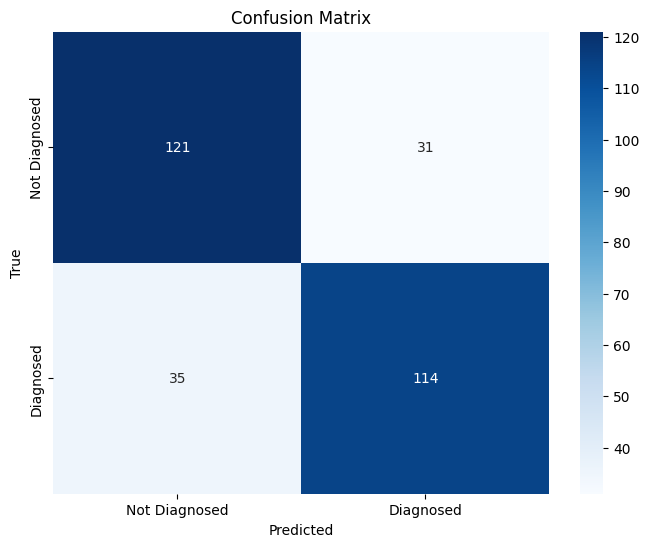

```
The amount of correctly predicted individuals, who did not have the condition (True negative): 121
The amount of correctly predicted individuals, who did have the condition (True positive): 114
The amount of incorrectly predicted individuals, predicted to have the condition, but actually did not (False positive): 31
The amount of incorrectly predicted individuals, predicted to not have the condition, but actually did (False negative): 35
```

```python
import matplotlib.pyplot as plt
import seaborn as sns
import numpy as np
from sklearn.metrics import confusion_matrix

# Convert predictions to binary (0 or 1) based on a 0.5 threshold
binary_predictions = np.where(predictions > 0.5, 1, 0)

# Generate the confusion matrix
cm = confusion_matrix(y_test, binary_predictions)

# Visualize the confusion matrix
plt.figure(figsize=(8, 6))
sns.heatmap(cm, annot=True, fmt="d", cmap="Blues", xticklabels=['Not Diagnosed', 'Diagnosed'], yticklabels=['Not Diagnosed', 'Diagnosed'])
plt.xlabel('Predicted')
plt.ylabel('True')
plt.title('Confusion Matrix')
plt.show()

# Extracting true negatives, false positives, false negatives, and true positives
tn, fp, fn, tp = cm.ravel()

# Printing the breakdown
print(f"The amount of correctly predicted individuals, who did not have the condition (True negative): {tn}")
print(f"The amount of correctly predicted individuals, who did have the condition (True positive): {tp}")
print(f"The amount of incorrectly predicted individuals, predicted to have the condition, but actually did not (False positive): {fp}")
print(f"The amount of incorrectly predicted individuals, predicted to not have the condition, but actually did (False negative): {fn}")
```

```python
from sklearn.metrics import confusion_matrix, classification_report, roc_curve, auc
import matplotlib.pyplot as plt
from tensorflow.keras.utils import plot_model

# Classification Report
cr = classification_report(y_test, binary_predictions)
print("\nClassification Report:")
print(cr)
```

```
Classification Report:
              precision    recall  f1-score   support

           0       0.78      0.80      0.79       152
           1       0.79      0.77      0.78       149

    accuracy                           0.78       301
   macro avg       0.78      0.78      0.78       301
weighted avg       0.78      0.78      0.78       301
```

### MLFFNN/MLP - 70/30 split with downsampled data

```python
# Import necessary libraries
import pandas as pd
from sklearn.model_selection import train_test_split
from sklearn.preprocessing import StandardScaler
from tensorflow.keras.models import Sequential
from tensorflow.keras.layers import Dense

X = balanced_data_downsampled.drop(['Diagnosis', 'AgeGroup'], axis=1)  # Features
y = balanced_data_downsampled['Diagnosis']  # Target variable

# Normalise the Data
scaler = StandardScaler()
X_scaled = scaler.fit_transform(X)

# Split into Training and Test Sets
X_train, X_test, y_train, y_test = train_test_split(X_scaled, y, test_size=0.3, random_state=42)

# Build the Neural Network Model
model = Sequential([
    Dense(16, activation='relu', input_shape=(X_train.shape[1],)),
    Dense(32, activation='relu'),  # Added layer with 32 neurons
    Dense(64, activation='relu'),  # Added layer with 64 neurons
    Dense(32, activation='relu'),  # Added another layer with 32 neurons
    Dense(16, activation='relu'),  # Original layer
    Dense(1, activation='sigmoid')
])

# Compile the Model
model.compile(optimizer='adam', loss='binary_crossentropy', metrics=['accuracy'])

# Train the Model
model.fit(X_train, y_train, epochs=150, validation_split=0.3)

# Evaluate the Model
loss, accuracy = model.evaluate(X_test, y_test)
print(f"Test Accuracy: {accuracy*100:.2f}%")

# Model Predictions
predictions = model.predict(X_test) > 0.5
```

```
23/23 ━━━━━━━━━━━━━━━━━━━━ 1s 8ms/step - accuracy: 0.4894 - loss: 0.6947 - val_accuracy: 0.4778 - val_loss: 0.6903
23/23 ━━━━━━━━━━━━━━━━━━━━ 0s 3ms/step - accuracy: 0.5537 - loss: 0.6688 - val_accuracy: 0.5696 - val_loss: 0.6811
23/23 ━━━━━━━━━━━━━━━━━━━━ 0s 2ms/step - accuracy: 0.6487 - loss: 0.6286 - val_accuracy: 0.6139 - val_loss: 0.6661
23/23 ━━━━━━━━━━━━━━━━━━━━ 0s 2ms/step - accuracy: 0.7414 - loss: 0.5467 - val_accuracy: 0.6772 - val_loss: 0.6605
23/23 ━━━━━━━━━━━━━━━━━━━━ 0s 2ms/step - accuracy: 0.7688 - loss: 0.4821 - val_accuracy: 0.6899 - val_loss: 0.6587
23/23 ━━━━━━━━━━━━━━━━━━━━ 0s 2ms/step - accuracy: 0.8004 - loss: 0.4461 - val_accuracy: 0.6899 - val_loss: 0.6529
23/23 ━━━━━━━━━━━━━━━━━━━━ 0s 2ms/step - accuracy: 0.8295 - loss: 0.3928 - val_accuracy: 0.6899 - val_loss: 0.6648
23/23 ━━━━━━━━━━━━━━━━━━━━ 0s 3ms/step - accuracy: 0.8402 - loss: 0.3401 - val_accuracy: 0.7215 - val_loss: 0.6665
23/23 ━━━━━━━━━━━━━━━━━━━━ 0s 2ms/step - accuracy: 0.8566 - loss: 0.3572 - val_accuracy: 0.7215 - val_loss: 0.6814
23/23 ━━━━━━━━━━━━━━━━━━━━ 0s 2ms/step - accuracy: 0.8785 - loss: 0.2891 - val_accuracy: 0.7342 - val_loss: 0.6982
23/23 ━━━━━━━━━━━━━━━━━━━━ 0s 2ms/step - accuracy: 0.8906 - loss: 0.2694 - val_accuracy: 0.7247 - val_loss: 0.7173
23/23 ━━━━━━━━━━━━━━━━━━━━ 0s 2ms/step - accuracy: 0.9160 - loss: 0.2347 - val_accuracy: 0.7310 - val_loss: 0.7587
23/23 ━━━━━━━━━━━━━━━━━━━━ 0s 2ms/step - accuracy: 0.9140 - loss: 0.2221 - val_accuracy: 0.7215 - val_loss: 0.8230
23/23 ━━━━━━━━━━━━━━━━━━━━ 0s 2ms/step - accuracy: 0.9404 - loss: 0.1776 - val_accuracy: 0.7278 - val_loss: 0.8242
23/23 ━━━━━━━━━━━━━━━━━━━━ 0s 2ms/step - accuracy: 0.9409 - loss: 0.1614 - val_accuracy: 0.7405 - val_loss: 0.8667
23/23 ━━━━━━━━━━━━━━━━━━━━ 0s 3ms/step - accuracy: 0.9522 - loss: 0.1714 - val_accuracy: 0.7405 - val_loss: 0.9303
23/23 ━━━━━━━━━━━━━━━━━━━━ 0s 3ms/step - accuracy: 0.9641 - loss: 0.1159 - val_accuracy: 0.7373 - val_loss: 1.0183
23/23 ━━━━━━━━━━━━━━━━━━━━ 0s 2ms/step - accuracy: 0.9777 - loss: 0.0968 - val_accuracy: 0.7405 - val_loss: 1.0711
23/23 ━━━━━━━━━━━━━━━━━━━━ 0s 2ms/step - accuracy: 0.9832 - loss: 0.0787 - val_accuracy: 0.7373 - val_loss: 1.1671
23/23 ━━━━━━━━━━━━━━━━━━━━ 0s 3ms/step - accuracy: 0.9759 - loss: 0.0736 - val_accuracy: 0.7278 - val_loss: 1.2768
23/23 ━━━━━━━━━━━━━━━━━━━━ 0s 2ms/step - accuracy: 0.9936 - loss: 0.0420 - val_accuracy: 0.7310 - val_loss: 1.3796
23/23 ━━━━━━━━━━━━━━━━━━━━ 0s 2ms/step - accuracy: 0.9993 - loss: 0.0237 - val_accuracy: 0.7215 - val_loss: 1.4803
23/23 ━━━━━━━━━━━━━━━━━━━━ 0s 2ms/step - accuracy: 0.9982 - loss: 0.0292 - val_accuracy: 0.7310 - val_loss: 1.5473
23/23 ━━━━━━━━━━━━━━━━━━━━ 0s 2ms/step - accuracy: 0.9988 - loss: 0.0167 - val_accuracy: 0.7247 - val_loss: 1.6310
23/23 ━━━━━━━━━━━━━━━━━━━━ 0s 2ms/step - accuracy: 0.9994 - loss: 0.0132 - val_accuracy: 0.7215 - val_loss: 1.7192
23/23 ━━━━━━━━━━━━━━━━━━━━ 0s 2ms/step - accuracy: 0.9977 - loss: 0.0122 - val_accuracy: 0.7247 - val_loss: 1.7936
23/23 ━━━━━━━━━━━━━━━━━━━━ 0s 2ms/step - accuracy: 0.9983 - loss: 0.0086 - val_accuracy: 0.7215 - val_loss: 1.8919
23/23 ━━━━━━━━━━━━━━━━━━━━ 0s 2ms/step - accuracy: 1.0000 - loss: 0.0057 - val_accuracy: 0.7184 - val_loss: 1.9831
23/23 ━━━━━━━━━━━━━━━━━━━━ 0s 2ms/step - accuracy: 1.0000 - loss: 0.0048 - val_accuracy: 0.7184 - val_loss: 2.0829
23/23 ━━━━━━━━━━━━━━━━━━━━ 0s 2ms/step - accuracy: 1.0000 - loss: 0.0038 - val_accuracy: 0.7120 - val_loss: 2.1671
23/23 ━━━━━━━━━━━━━━━━━━━━ 0s 2ms/step - accuracy: 1.0000 - loss: 0.0026 - val_accuracy: 0.7120 - val_loss: 2.2314
23/23 ━━━━━━━━━━━━━━━━━━━━ 0s 2ms/step - accuracy: 1.0000 - loss: 0.0021 - val_accuracy: 0.7152 - val_loss: 2.2993
23/23 ━━━━━━━━━━━━━━━━━━━━ 0s 2ms/step - accuracy: 1.0000 - loss: 0.0015 - val_accuracy: 0.7120 - val_loss: 2.3586
23/23 ━━━━━━━━━━━━━━━━━━━━ 0s 2ms/step - accuracy: 1.0000 - loss: 0.0016 - val_accuracy: 0.7120 - val_loss: 2.4154
23/23 ━━━━━━━━━━━━━━━━━━━━ 0s 2ms/step - accuracy: 1.0000 - loss: 0.0013 - val_accuracy: 0.7152 - val_loss: 2.4655
23/23 ━━━━━━━━━━━━━━━━━━━━ 0s 2ms/step - accuracy: 1.0000 - loss: 0.0013 - val_accuracy: 0.7152 - val_loss: 2.5115
23/23 ━━━━━━━━━━━━━━━━━━━━ 0s 2ms/step - accuracy: 1.0000 - loss: 0.0010 - val_accuracy: 0.7120 - val_loss: 2.5581
23/23 ━━━━━━━━━━━━━━━━━━━━ 0s 2ms/step - accuracy: 1.0000 - loss: 0.0011 - val_accuracy: 0.7184 - val_loss: 2.6002
23/23 ━━━━━━━━━━━━━━━━━━━━ 0s 2ms/step - accuracy: 1.0000 - loss: 7.7966e-04 - val_accuracy: 0.7152 - val_loss: 2.6406
23/23 ━━━━━━━━━━━━━━━━━━━━ 0s 2ms/step - accuracy: 1.0000 - loss: 8.0287e-04 - val_accuracy: 0.7184 - val_loss: 2.6786
```

[output cut: 98 more lines]

```
23/23 ━━━━━━━━━━━━━━━━━━━━ 0s 2ms/step - accuracy: 1.0000 - loss: 4.1686e-06 - val_accuracy: 0.7152 - val_loss: 4.7918
23/23 ━━━━━━━━━━━━━━━━━━━━ 0s 2ms/step - accuracy: 1.0000 - loss: 4.2115e-06 - val_accuracy: 0.7152 - val_loss: 4.8046
23/23 ━━━━━━━━━━━━━━━━━━━━ 0s 2ms/step - accuracy: 1.0000 - loss: 4.6907e-06 - val_accuracy: 0.7152 - val_loss: 4.8148
23/23 ━━━━━━━━━━━━━━━━━━━━ 0s 2ms/step - accuracy: 1.0000 - loss: 4.4924e-06 - val_accuracy: 0.7152 - val_loss: 4.8236
23/23 ━━━━━━━━━━━━━━━━━━━━ 0s 2ms/step - accuracy: 1.0000 - loss: 3.5120e-06 - val_accuracy: 0.7152 - val_loss: 4.8345
23/23 ━━━━━━━━━━━━━━━━━━━━ 0s 2ms/step - accuracy: 1.0000 - loss: 3.4672e-06 - val_accuracy: 0.7152 - val_loss: 4.8436
23/23 ━━━━━━━━━━━━━━━━━━━━ 0s 2ms/step - accuracy: 1.0000 - loss: 2.8341e-06 - val_accuracy: 0.7152 - val_loss: 4.8543
23/23 ━━━━━━━━━━━━━━━━━━━━ 0s 2ms/step - accuracy: 1.0000 - loss: 3.3027e-06 - val_accuracy: 0.7152 - val_loss: 4.8647
23/23 ━━━━━━━━━━━━━━━━━━━━ 0s 2ms/step - accuracy: 1.0000 - loss: 3.7058e-06 - val_accuracy: 0.7152 - val_loss: 4.8763
23/23 ━━━━━━━━━━━━━━━━━━━━ 0s 2ms/step - accuracy: 1.0000 - loss: 3.1299e-06 - val_accuracy: 0.7152 - val_loss: 4.8844
23/23 ━━━━━━━━━━━━━━━━━━━━ 0s 2ms/step - accuracy: 1.0000 - loss: 3.4163e-06 - val_accuracy: 0.7152 - val_loss: 4.8938
23/23 ━━━━━━━━━━━━━━━━━━━━ 0s 2ms/step - accuracy: 1.0000 - loss: 4.2109e-06 - val_accuracy: 0.7152 - val_loss: 4.9042
15/15 ━━━━━━━━━━━━━━━━━━━━ 0s 888us/step - accuracy: 0.7599 - loss: 3.3018
Test Accuracy: 76.77%
15/15 ━━━━━━━━━━━━━━━━━━━━ 0s 2ms/step
```

Evaluation of model 70/30 - DS

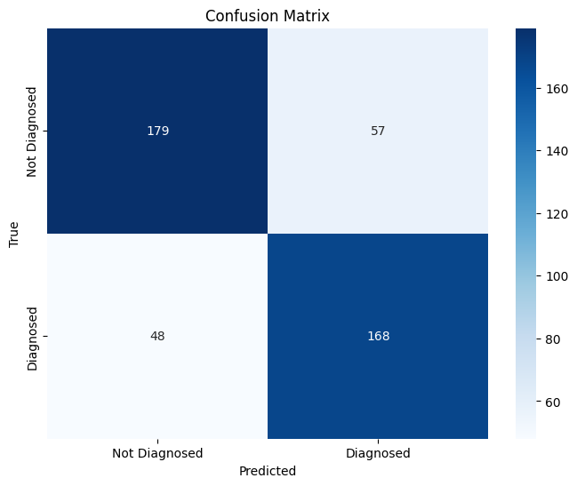

```
The amount of correctly predicted individuals, who did not have the condition (True negative): 179
The amount of correctly predicted individuals, who did have the condition (True positive): 168
The amount of incorrectly predicted individuals, predicted to have the condition, but actually did not (False positive): 57
The amount of incorrectly predicted individuals, predicted to not have the condition, but actually did (False negative): 48
```

```python
import matplotlib.pyplot as plt
import seaborn as sns
import numpy as np
from sklearn.metrics import confusion_matrix

# Convert predictions to binary (0 or 1) based on a 0.5 threshold
binary_predictions = np.where(predictions > 0.5, 1, 0)

# Generate the confusion matrix
cm = confusion_matrix(y_test, binary_predictions)

# Visualize the confusion matrix
plt.figure(figsize=(8, 6))
sns.heatmap(cm, annot=True, fmt="d", cmap="Blues", xticklabels=['Not Diagnosed', 'Diagnosed'], yticklabels=['Not Diagnosed', 'Diagnosed'])
plt.xlabel('Predicted')
plt.ylabel('True')
plt.title('Confusion Matrix')
plt.show()

# Extracting true negatives, false positives, false negatives, and true positives
tn, fp, fn, tp = cm.ravel()

# Printing the breakdown
print(f"The amount of correctly predicted individuals, who did not have the condition (True negative): {tn}")
print(f"The amount of correctly predicted individuals, who did have the condition (True positive): {tp}")
print(f"The amount of incorrectly predicted individuals, predicted to have the condition, but actually did not (False positive): {fp}")
print(f"The amount of incorrectly predicted individuals, predicted to not have the condition, but actually did (False negative): {fn}")
```

```python
from sklearn.metrics import confusion_matrix, classification_report, roc_curve, auc
import matplotlib.pyplot as plt
from tensorflow.keras.utils import plot_model

# Classification Report
cr = classification_report(y_test, binary_predictions)
print("\nClassification Report:")
print(cr)
```

```
Classification Report:
              precision    recall  f1-score   support

           0       0.79      0.76      0.77       236
           1       0.75      0.78      0.76       216

    accuracy                           0.77       452
   macro avg       0.77      0.77      0.77       452
weighted avg       0.77      0.77      0.77       452
```

### MLFFNN/MLP - 80/20 split with upsampled data

```python
# Import necessary libraries
import pandas as pd
from sklearn.model_selection import train_test_split
from sklearn.preprocessing import StandardScaler
from tensorflow.keras.models import Sequential
from tensorflow.keras.layers import Dense

X = balanced_data_smote.drop(['Diagnosis'], axis=1)  # Features
y = balanced_data_smote['Diagnosis']  # Target variable

# Normalise the Data
scaler = StandardScaler()
X_scaled = scaler.fit_transform(X)

# Split into Training and Test Sets
X_train, X_test, y_train, y_test = train_test_split(X_scaled, y, test_size=0.2, random_state=42)

# Build the Neural Network Model
model = Sequential([
    Dense(16, activation='relu', input_shape=(X_train.shape[1],)),
    Dense(32, activation='relu'),  # Added layer with 32 neurons
    Dense(64, activation='relu'),  # Added layer with 64 neurons
    Dense(32, activation='relu'),  # Added another layer with 32 neurons
    Dense(16, activation='relu'),  # Original layer
    Dense(1, activation='sigmoid')
])

# Compile the Model
model.compile(optimizer='adam', loss='binary_crossentropy', metrics=['accuracy'])

# Train the Model
model.fit(X_train, y_train, epochs=150, validation_split=0.2)

# Evaluate the Model
loss, accuracy = model.evaluate(X_test, y_test)
print(f"Test Accuracy: {accuracy*100:.2f}%")

# Model Predictions
predictions = model.predict(X_test) > 0.5
```

```
46/46 ━━━━━━━━━━━━━━━━━━━━ 1s 4ms/step - accuracy: 0.5197 - loss: 0.6900 - val_accuracy: 0.6482 - val_loss: 0.6523
46/46 ━━━━━━━━━━━━━━━━━━━━ 0s 2ms/step - accuracy: 0.6589 - loss: 0.6339 - val_accuracy: 0.7008 - val_loss: 0.5820
46/46 ━━━━━━━━━━━━━━━━━━━━ 0s 1ms/step - accuracy: 0.7247 - loss: 0.5546 - val_accuracy: 0.7396 - val_loss: 0.5277
46/46 ━━━━━━━━━━━━━━━━━━━━ 0s 1ms/step - accuracy: 0.7972 - loss: 0.4547 - val_accuracy: 0.7673 - val_loss: 0.4980
46/46 ━━━━━━━━━━━━━━━━━━━━ 0s 1ms/step - accuracy: 0.8257 - loss: 0.3903 - val_accuracy: 0.7756 - val_loss: 0.4991
46/46 ━━━━━━━━━━━━━━━━━━━━ 0s 2ms/step - accuracy: 0.8422 - loss: 0.3851 - val_accuracy: 0.7701 - val_loss: 0.5009
46/46 ━━━━━━━━━━━━━━━━━━━━ 0s 1ms/step - accuracy: 0.8555 - loss: 0.3436 - val_accuracy: 0.7645 - val_loss: 0.4947
46/46 ━━━━━━━━━━━━━━━━━━━━ 0s 1ms/step - accuracy: 0.8784 - loss: 0.3042 - val_accuracy: 0.7784 - val_loss: 0.4948
46/46 ━━━━━━━━━━━━━━━━━━━━ 0s 1ms/step - accuracy: 0.8862 - loss: 0.2837 - val_accuracy: 0.7756 - val_loss: 0.5109
46/46 ━━━━━━━━━━━━━━━━━━━━ 0s 1ms/step - accuracy: 0.8978 - loss: 0.2872 - val_accuracy: 0.7867 - val_loss: 0.5107
46/46 ━━━━━━━━━━━━━━━━━━━━ 0s 1ms/step - accuracy: 0.9064 - loss: 0.2469 - val_accuracy: 0.7645 - val_loss: 0.5275
46/46 ━━━━━━━━━━━━━━━━━━━━ 0s 1ms/step - accuracy: 0.9002 - loss: 0.2672 - val_accuracy: 0.7895 - val_loss: 0.5271
46/46 ━━━━━━━━━━━━━━━━━━━━ 0s 1ms/step - accuracy: 0.8952 - loss: 0.2624 - val_accuracy: 0.7756 - val_loss: 0.5525
46/46 ━━━━━━━━━━━━━━━━━━━━ 0s 1ms/step - accuracy: 0.9287 - loss: 0.2119 - val_accuracy: 0.7645 - val_loss: 0.5828
46/46 ━━━━━━━━━━━━━━━━━━━━ 0s 1ms/step - accuracy: 0.9234 - loss: 0.2069 - val_accuracy: 0.7867 - val_loss: 0.6203
46/46 ━━━━━━━━━━━━━━━━━━━━ 0s 1ms/step - accuracy: 0.9227 - loss: 0.1969 - val_accuracy: 0.7729 - val_loss: 0.6539
46/46 ━━━━━━━━━━━━━━━━━━━━ 0s 1ms/step - accuracy: 0.9431 - loss: 0.1755 - val_accuracy: 0.7673 - val_loss: 0.6762
46/46 ━━━━━━━━━━━━━━━━━━━━ 0s 1ms/step - accuracy: 0.9550 - loss: 0.1335 - val_accuracy: 0.7701 - val_loss: 0.7265
46/46 ━━━━━━━━━━━━━━━━━━━━ 0s 1ms/step - accuracy: 0.9473 - loss: 0.1448 - val_accuracy: 0.7729 - val_loss: 0.7578
46/46 ━━━━━━━━━━━━━━━━━━━━ 0s 1ms/step - accuracy: 0.9663 - loss: 0.1226 - val_accuracy: 0.7729 - val_loss: 0.8299
46/46 ━━━━━━━━━━━━━━━━━━━━ 0s 2ms/step - accuracy: 0.9803 - loss: 0.0890 - val_accuracy: 0.7729 - val_loss: 0.8513
46/46 ━━━━━━━━━━━━━━━━━━━━ 0s 1ms/step - accuracy: 0.9645 - loss: 0.1085 - val_accuracy: 0.7590 - val_loss: 0.8675
46/46 ━━━━━━━━━━━━━━━━━━━━ 0s 1ms/step - accuracy: 0.9708 - loss: 0.1087 - val_accuracy: 0.7535 - val_loss: 0.9380
46/46 ━━━━━━━━━━━━━━━━━━━━ 0s 2ms/step - accuracy: 0.9758 - loss: 0.0719 - val_accuracy: 0.7479 - val_loss: 0.9649
46/46 ━━━━━━━━━━━━━━━━━━━━ 0s 1ms/step - accuracy: 0.9802 - loss: 0.0762 - val_accuracy: 0.7535 - val_loss: 0.9934
46/46 ━━━━━━━━━━━━━━━━━━━━ 0s 2ms/step - accuracy: 0.9813 - loss: 0.0629 - val_accuracy: 0.7729 - val_loss: 1.0528
46/46 ━━━━━━━━━━━━━━━━━━━━ 0s 2ms/step - accuracy: 0.9854 - loss: 0.0541 - val_accuracy: 0.7729 - val_loss: 1.1120
46/46 ━━━━━━━━━━━━━━━━━━━━ 0s 1ms/step - accuracy: 0.9790 - loss: 0.0568 - val_accuracy: 0.7645 - val_loss: 1.1559
46/46 ━━━━━━━━━━━━━━━━━━━━ 0s 1ms/step - accuracy: 0.9739 - loss: 0.0621 - val_accuracy: 0.7673 - val_loss: 1.2179
46/46 ━━━━━━━━━━━━━━━━━━━━ 0s 2ms/step - accuracy: 0.9925 - loss: 0.0379 - val_accuracy: 0.7729 - val_loss: 1.3104
46/46 ━━━━━━━━━━━━━━━━━━━━ 0s 1ms/step - accuracy: 0.9946 - loss: 0.0252 - val_accuracy: 0.7590 - val_loss: 1.3099
46/46 ━━━━━━━━━━━━━━━━━━━━ 0s 1ms/step - accuracy: 0.9940 - loss: 0.0223 - val_accuracy: 0.7645 - val_loss: 1.4063
46/46 ━━━━━━━━━━━━━━━━━━━━ 0s 2ms/step - accuracy: 0.9875 - loss: 0.0251 - val_accuracy: 0.7673 - val_loss: 1.4895
46/46 ━━━━━━━━━━━━━━━━━━━━ 0s 2ms/step - accuracy: 0.9924 - loss: 0.0220 - val_accuracy: 0.7590 - val_loss: 1.5638
46/46 ━━━━━━━━━━━━━━━━━━━━ 0s 2ms/step - accuracy: 0.9967 - loss: 0.0127 - val_accuracy: 0.7562 - val_loss: 1.6241
46/46 ━━━━━━━━━━━━━━━━━━━━ 0s 2ms/step - accuracy: 0.9971 - loss: 0.0132 - val_accuracy: 0.7562 - val_loss: 1.6717
46/46 ━━━━━━━━━━━━━━━━━━━━ 0s 1ms/step - accuracy: 0.9944 - loss: 0.0174 - val_accuracy: 0.7618 - val_loss: 1.7765
46/46 ━━━━━━━━━━━━━━━━━━━━ 0s 1ms/step - accuracy: 0.9957 - loss: 0.0131 - val_accuracy: 0.7590 - val_loss: 1.8127
46/46 ━━━━━━━━━━━━━━━━━━━━ 0s 1ms/step - accuracy: 0.9991 - loss: 0.0077 - val_accuracy: 0.7562 - val_loss: 1.8976
46/46 ━━━━━━━━━━━━━━━━━━━━ 0s 1ms/step - accuracy: 0.9987 - loss: 0.0076 - val_accuracy: 0.7590 - val_loss: 1.9651
```

[output cut: 98 more lines]

```
46/46 ━━━━━━━━━━━━━━━━━━━━ 0s 2ms/step - accuracy: 1.0000 - loss: 9.6814e-06 - val_accuracy: 0.7562 - val_loss: 4.4989
46/46 ━━━━━━━━━━━━━━━━━━━━ 0s 1ms/step - accuracy: 1.0000 - loss: 1.0223e-05 - val_accuracy: 0.7562 - val_loss: 4.5134
46/46 ━━━━━━━━━━━━━━━━━━━━ 0s 2ms/step - accuracy: 1.0000 - loss: 1.1002e-05 - val_accuracy: 0.7562 - val_loss: 4.5304
46/46 ━━━━━━━━━━━━━━━━━━━━ 0s 2ms/step - accuracy: 1.0000 - loss: 1.0468e-05 - val_accuracy: 0.7562 - val_loss: 4.5383
46/46 ━━━━━━━━━━━━━━━━━━━━ 0s 2ms/step - accuracy: 1.0000 - loss: 1.0944e-05 - val_accuracy: 0.7562 - val_loss: 4.5529
46/46 ━━━━━━━━━━━━━━━━━━━━ 0s 1ms/step - accuracy: 1.0000 - loss: 8.9434e-06 - val_accuracy: 0.7562 - val_loss: 4.5645
46/46 ━━━━━━━━━━━━━━━━━━━━ 0s 2ms/step - accuracy: 1.0000 - loss: 8.5290e-06 - val_accuracy: 0.7562 - val_loss: 4.5763
46/46 ━━━━━━━━━━━━━━━━━━━━ 0s 1ms/step - accuracy: 1.0000 - loss: 8.0029e-06 - val_accuracy: 0.7562 - val_loss: 4.5881
46/46 ━━━━━━━━━━━━━━━━━━━━ 0s 1ms/step - accuracy: 1.0000 - loss: 6.9381e-06 - val_accuracy: 0.7562 - val_loss: 4.6006
46/46 ━━━━━━━━━━━━━━━━━━━━ 0s 1ms/step - accuracy: 1.0000 - loss: 8.5478e-06 - val_accuracy: 0.7562 - val_loss: 4.6114
46/46 ━━━━━━━━━━━━━━━━━━━━ 0s 2ms/step - accuracy: 1.0000 - loss: 6.0684e-06 - val_accuracy: 0.7562 - val_loss: 4.6226
46/46 ━━━━━━━━━━━━━━━━━━━━ 0s 2ms/step - accuracy: 1.0000 - loss: 8.4249e-06 - val_accuracy: 0.7562 - val_loss: 4.6350
15/15 ━━━━━━━━━━━━━━━━━━━━ 0s 714us/step - accuracy: 0.7897 - loss: 2.7709
Test Accuracy: 78.94%
15/15 ━━━━━━━━━━━━━━━━━━━━ 0s 3ms/step
```

Evaluation of model 80/20 - US

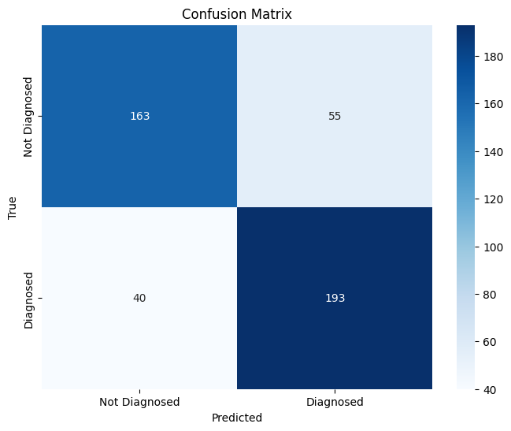

```
The amount of correctly predicted individuals, who did not have the condition (True negative): 163
The amount of correctly predicted individuals, who did have the condition (True positive): 193
The amount of incorrectly predicted individuals, predicted to have the condition, but actually did not (False positive): 55
The amount of incorrectly predicted individuals, predicted to not have the condition, but actually did (False negative): 40
```

```python
import matplotlib.pyplot as plt
import seaborn as sns
import numpy as np
from sklearn.metrics import confusion_matrix

# Convert predictions to binary (0 or 1) based on a 0.5 threshold
binary_predictions = np.where(predictions > 0.5, 1, 0)

# Generate the confusion matrix
cm = confusion_matrix(y_test, binary_predictions)

# Visualize the confusion matrix
plt.figure(figsize=(8, 6))
sns.heatmap(cm, annot=True, fmt="d", cmap="Blues", xticklabels=['Not Diagnosed', 'Diagnosed'], yticklabels=['Not Diagnosed', 'Diagnosed'])
plt.xlabel('Predicted')
plt.ylabel('True')
plt.title('Confusion Matrix')
plt.show()

# Extracting true negatives, false positives, false negatives, and true positives
tn, fp, fn, tp = cm.ravel()

# Printing the breakdown
print(f"The amount of correctly predicted individuals, who did not have the condition (True negative): {tn}")
print(f"The amount of correctly predicted individuals, who did have the condition (True positive): {tp}")
print(f"The amount of incorrectly predicted individuals, predicted to have the condition, but actually did not (False positive): {fp}")
print(f"The amount of incorrectly predicted individuals, predicted to not have the condition, but actually did (False negative): {fn}")
```

```python
from sklearn.metrics import confusion_matrix, classification_report, roc_curve, auc
import matplotlib.pyplot as plt
from tensorflow.keras.utils import plot_model

# Classification Report
cr = classification_report(y_test, binary_predictions)
print("\nClassification Report:")
print(cr)
```

```
Classification Report:
              precision    recall  f1-score   support

           0       0.80      0.75      0.77       218
           1       0.78      0.83      0.80       233

    accuracy                           0.79       451
   macro avg       0.79      0.79      0.79       451
weighted avg       0.79      0.79      0.79       451
```

### MLFFNN/MLP - 70/30 split with upsampled data

```python
# Import necessary libraries
import pandas as pd
from sklearn.model_selection import train_test_split
from sklearn.preprocessing import StandardScaler
from tensorflow.keras.models import Sequential
from tensorflow.keras.layers import Dense

X = balanced_data_smote.drop(['Diagnosis'], axis=1)  # Features
y = balanced_data_smote['Diagnosis']  # Target variable

# Normalise the Data
scaler = StandardScaler()
X_scaled = scaler.fit_transform(X)

# Split into Training and Test Sets
X_train, X_test, y_train, y_test = train_test_split(X_scaled, y, test_size=0.3, random_state=42)

# Build the Neural Network Model
model = Sequential([
    Dense(16, activation='relu', input_shape=(X_train.shape[1],)),
    Dense(32, activation='relu'),  # Added layer with 32 neurons
    Dense(64, activation='relu'),  # Added layer with 64 neurons
    Dense(32, activation='relu'),  # Added another layer with 32 neurons
    Dense(16, activation='relu'),  # Original layer
    Dense(1, activation='sigmoid')
])

# Compile the Model
model.compile(optimizer='adam', loss='binary_crossentropy', metrics=['accuracy'])

# Train the Model
model.fit(X_train, y_train, epochs=150, validation_split=0.3)

# Evaluate the Model
loss, accuracy = model.evaluate(X_test, y_test)
print(f"Test Accuracy: {accuracy*100:.2f}%")

# Model Predictions
predictions = model.predict(X_test) > 0.5
```

```
35/35 ━━━━━━━━━━━━━━━━━━━━ 1s 5ms/step - accuracy: 0.5372 - loss: 0.6831 - val_accuracy: 0.6477 - val_loss: 0.6583
35/35 ━━━━━━━━━━━━━━━━━━━━ 0s 1ms/step - accuracy: 0.6714 - loss: 0.6379 - val_accuracy: 0.7194 - val_loss: 0.5971
35/35 ━━━━━━━━━━━━━━━━━━━━ 0s 1ms/step - accuracy: 0.7315 - loss: 0.5808 - val_accuracy: 0.7658 - val_loss: 0.5209
35/35 ━━━━━━━━━━━━━━━━━━━━ 0s 1ms/step - accuracy: 0.7249 - loss: 0.5246 - val_accuracy: 0.7869 - val_loss: 0.4709
35/35 ━━━━━━━━━━━━━━━━━━━━ 0s 1ms/step - accuracy: 0.7788 - loss: 0.4579 - val_accuracy: 0.7996 - val_loss: 0.4416
35/35 ━━━━━━━━━━━━━━━━━━━━ 0s 1ms/step - accuracy: 0.8175 - loss: 0.4255 - val_accuracy: 0.8122 - val_loss: 0.4149
35/35 ━━━━━━━━━━━━━━━━━━━━ 0s 1ms/step - accuracy: 0.8446 - loss: 0.3714 - val_accuracy: 0.8059 - val_loss: 0.4117
35/35 ━━━━━━━━━━━━━━━━━━━━ 0s 1ms/step - accuracy: 0.8513 - loss: 0.3411 - val_accuracy: 0.8101 - val_loss: 0.3995
35/35 ━━━━━━━━━━━━━━━━━━━━ 0s 1ms/step - accuracy: 0.8609 - loss: 0.3026 - val_accuracy: 0.8207 - val_loss: 0.4053
35/35 ━━━━━━━━━━━━━━━━━━━━ 0s 1ms/step - accuracy: 0.9054 - loss: 0.2477 - val_accuracy: 0.8101 - val_loss: 0.4138
35/35 ━━━━━━━━━━━━━━━━━━━━ 0s 1ms/step - accuracy: 0.9074 - loss: 0.2501 - val_accuracy: 0.8101 - val_loss: 0.4268
35/35 ━━━━━━━━━━━━━━━━━━━━ 0s 1ms/step - accuracy: 0.9279 - loss: 0.2049 - val_accuracy: 0.8059 - val_loss: 0.4457
35/35 ━━━━━━━━━━━━━━━━━━━━ 0s 1ms/step - accuracy: 0.9343 - loss: 0.2042 - val_accuracy: 0.8059 - val_loss: 0.4739
35/35 ━━━━━━━━━━━━━━━━━━━━ 0s 1ms/step - accuracy: 0.9326 - loss: 0.1909 - val_accuracy: 0.7911 - val_loss: 0.4980
35/35 ━━━━━━━━━━━━━━━━━━━━ 0s 1ms/step - accuracy: 0.9453 - loss: 0.1682 - val_accuracy: 0.7806 - val_loss: 0.5392
35/35 ━━━━━━━━━━━━━━━━━━━━ 0s 1ms/step - accuracy: 0.9550 - loss: 0.1436 - val_accuracy: 0.7827 - val_loss: 0.5662
35/35 ━━━━━━━━━━━━━━━━━━━━ 0s 1ms/step - accuracy: 0.9617 - loss: 0.1243 - val_accuracy: 0.7869 - val_loss: 0.6123
35/35 ━━━━━━━━━━━━━━━━━━━━ 0s 2ms/step - accuracy: 0.9787 - loss: 0.0876 - val_accuracy: 0.7869 - val_loss: 0.6658
35/35 ━━━━━━━━━━━━━━━━━━━━ 0s 1ms/step - accuracy: 0.9740 - loss: 0.0953 - val_accuracy: 0.7679 - val_loss: 0.7211
35/35 ━━━━━━━━━━━━━━━━━━━━ 0s 1ms/step - accuracy: 0.9819 - loss: 0.0681 - val_accuracy: 0.7700 - val_loss: 0.7844
35/35 ━━━━━━━━━━━━━━━━━━━━ 0s 1ms/step - accuracy: 0.9868 - loss: 0.0674 - val_accuracy: 0.7806 - val_loss: 0.8269
35/35 ━━━━━━━━━━━━━━━━━━━━ 0s 1ms/step - accuracy: 0.9885 - loss: 0.0524 - val_accuracy: 0.7827 - val_loss: 0.8686
35/35 ━━━━━━━━━━━━━━━━━━━━ 0s 1ms/step - accuracy: 0.9889 - loss: 0.0413 - val_accuracy: 0.7637 - val_loss: 0.9529
35/35 ━━━━━━━━━━━━━━━━━━━━ 0s 1ms/step - accuracy: 0.9917 - loss: 0.0338 - val_accuracy: 0.7679 - val_loss: 1.0046
35/35 ━━━━━━━━━━━━━━━━━━━━ 0s 1ms/step - accuracy: 0.9944 - loss: 0.0230 - val_accuracy: 0.7679 - val_loss: 1.0699
35/35 ━━━━━━━━━━━━━━━━━━━━ 0s 1ms/step - accuracy: 0.9977 - loss: 0.0171 - val_accuracy: 0.7658 - val_loss: 1.1330
35/35 ━━━━━━━━━━━━━━━━━━━━ 0s 1ms/step - accuracy: 0.9983 - loss: 0.0171 - val_accuracy: 0.7722 - val_loss: 1.1785
35/35 ━━━━━━━━━━━━━━━━━━━━ 0s 1ms/step - accuracy: 0.9997 - loss: 0.0116 - val_accuracy: 0.7722 - val_loss: 1.2334
35/35 ━━━━━━━━━━━━━━━━━━━━ 0s 1ms/step - accuracy: 0.9999 - loss: 0.0080 - val_accuracy: 0.7743 - val_loss: 1.2623
35/35 ━━━━━━━━━━━━━━━━━━━━ 0s 1ms/step - accuracy: 0.9985 - loss: 0.0075 - val_accuracy: 0.7700 - val_loss: 1.3251
35/35 ━━━━━━━━━━━━━━━━━━━━ 0s 1ms/step - accuracy: 1.0000 - loss: 0.0056 - val_accuracy: 0.7743 - val_loss: 1.3755
35/35 ━━━━━━━━━━━━━━━━━━━━ 0s 1ms/step - accuracy: 1.0000 - loss: 0.0050 - val_accuracy: 0.7743 - val_loss: 1.4338
35/35 ━━━━━━━━━━━━━━━━━━━━ 0s 1ms/step - accuracy: 1.0000 - loss: 0.0032 - val_accuracy: 0.7743 - val_loss: 1.4677
35/35 ━━━━━━━━━━━━━━━━━━━━ 0s 1ms/step - accuracy: 1.0000 - loss: 0.0027 - val_accuracy: 0.7743 - val_loss: 1.5225
35/35 ━━━━━━━━━━━━━━━━━━━━ 0s 1ms/step - accuracy: 1.0000 - loss: 0.0027 - val_accuracy: 0.7722 - val_loss: 1.5516
35/35 ━━━━━━━━━━━━━━━━━━━━ 0s 1ms/step - accuracy: 1.0000 - loss: 0.0022 - val_accuracy: 0.7722 - val_loss: 1.6140
35/35 ━━━━━━━━━━━━━━━━━━━━ 0s 1ms/step - accuracy: 1.0000 - loss: 0.0020 - val_accuracy: 0.7722 - val_loss: 1.6338
35/35 ━━━━━━━━━━━━━━━━━━━━ 0s 1ms/step - accuracy: 1.0000 - loss: 0.0017 - val_accuracy: 0.7722 - val_loss: 1.6711
35/35 ━━━━━━━━━━━━━━━━━━━━ 0s 1ms/step - accuracy: 1.0000 - loss: 0.0014 - val_accuracy: 0.7722 - val_loss: 1.6962
35/35 ━━━━━━━━━━━━━━━━━━━━ 0s 1ms/step - accuracy: 1.0000 - loss: 0.0014 - val_accuracy: 0.7722 - val_loss: 1.7211
```

[output cut: 98 more lines]

```
35/35 ━━━━━━━━━━━━━━━━━━━━ 0s 1ms/step - accuracy: 1.0000 - loss: 2.0955e-05 - val_accuracy: 0.7700 - val_loss: 2.8756
35/35 ━━━━━━━━━━━━━━━━━━━━ 0s 1ms/step - accuracy: 1.0000 - loss: 1.6929e-05 - val_accuracy: 0.7700 - val_loss: 2.8852
35/35 ━━━━━━━━━━━━━━━━━━━━ 0s 1ms/step - accuracy: 1.0000 - loss: 1.3886e-05 - val_accuracy: 0.7700 - val_loss: 2.8899
35/35 ━━━━━━━━━━━━━━━━━━━━ 0s 1ms/step - accuracy: 1.0000 - loss: 1.4114e-05 - val_accuracy: 0.7700 - val_loss: 2.8991
35/35 ━━━━━━━━━━━━━━━━━━━━ 0s 1ms/step - accuracy: 1.0000 - loss: 1.8161e-05 - val_accuracy: 0.7700 - val_loss: 2.9050
35/35 ━━━━━━━━━━━━━━━━━━━━ 0s 1ms/step - accuracy: 1.0000 - loss: 1.6032e-05 - val_accuracy: 0.7700 - val_loss: 2.9130
35/35 ━━━━━━━━━━━━━━━━━━━━ 0s 1ms/step - accuracy: 1.0000 - loss: 1.6229e-05 - val_accuracy: 0.7700 - val_loss: 2.9188
35/35 ━━━━━━━━━━━━━━━━━━━━ 0s 2ms/step - accuracy: 1.0000 - loss: 1.4929e-05 - val_accuracy: 0.7700 - val_loss: 2.9269
35/35 ━━━━━━━━━━━━━━━━━━━━ 0s 1ms/step - accuracy: 1.0000 - loss: 1.0768e-05 - val_accuracy: 0.7700 - val_loss: 2.9331
35/35 ━━━━━━━━━━━━━━━━━━━━ 0s 1ms/step - accuracy: 1.0000 - loss: 1.4030e-05 - val_accuracy: 0.7700 - val_loss: 2.9391
35/35 ━━━━━━━━━━━━━━━━━━━━ 0s 1ms/step - accuracy: 1.0000 - loss: 1.0940e-05 - val_accuracy: 0.7700 - val_loss: 2.9474
35/35 ━━━━━━━━━━━━━━━━━━━━ 0s 1ms/step - accuracy: 1.0000 - loss: 1.0938e-05 - val_accuracy: 0.7700 - val_loss: 2.9554
22/22 ━━━━━━━━━━━━━━━━━━━━ 0s 563us/step - accuracy: 0.7785 - loss: 3.2015
Test Accuracy: 78.29%
22/22 ━━━━━━━━━━━━━━━━━━━━ 0s 2ms/step
```

Evalluation of model 70/30 - US

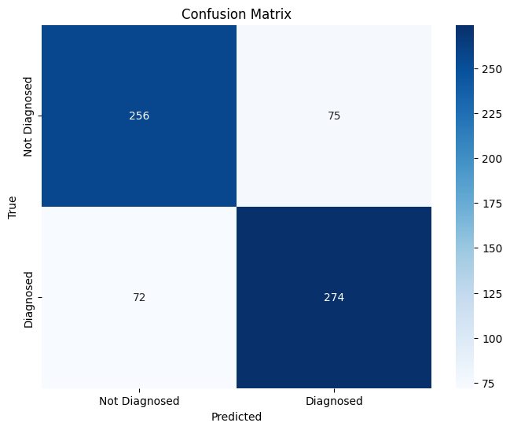

```
The amount of correctly predicted individuals, who did not have the condition (True negative): 256
The amount of correctly predicted individuals, who did have the condition (True positive): 274
The amount of incorrectly predicted individuals, predicted to have the condition, but actually did not (False positive): 75
The amount of incorrectly predicted individuals, predicted to not have the condition, but actually did (False negative): 72
```

```python
import matplotlib.pyplot as plt
import seaborn as sns
import numpy as np
from sklearn.metrics import confusion_matrix

# Convert predictions to binary (0 or 1) based on a 0.5 threshold
binary_predictions = np.where(predictions > 0.5, 1, 0)

# Generate the confusion matrix
cm = confusion_matrix(y_test, binary_predictions)

# Visualize the confusion matrix
plt.figure(figsize=(8, 6))
sns.heatmap(cm, annot=True, fmt="d", cmap="Blues", xticklabels=['Not Diagnosed', 'Diagnosed'], yticklabels=['Not Diagnosed', 'Diagnosed'])
plt.xlabel('Predicted')
plt.ylabel('True')
plt.title('Confusion Matrix')
plt.show()

# Extracting true negatives, false positives, false negatives, and true positives
tn, fp, fn, tp = cm.ravel()

# Printing the breakdown
print(f"The amount of correctly predicted individuals, who did not have the condition (True negative): {tn}")
print(f"The amount of correctly predicted individuals, who did have the condition (True positive): {tp}")
print(f"The amount of incorrectly predicted individuals, predicted to have the condition, but actually did not (False positive): {fp}")
print(f"The amount of incorrectly predicted individuals, predicted to not have the condition, but actually did (False negative): {fn}")
```

```python
from sklearn.metrics import confusion_matrix, classification_report, roc_curve, auc
import matplotlib.pyplot as plt
from tensorflow.keras.utils import plot_model

# Classification Report
cr = classification_report(y_test, binary_predictions)
print("\nClassification Report:")
print(cr)
```

```
Classification Report:
              precision    recall  f1-score   support

           0       0.78      0.77      0.78       331
           1       0.79      0.79      0.79       346

    accuracy                           0.78       677
   macro avg       0.78      0.78      0.78       677
weighted avg       0.78      0.78      0.78       677
```

### Conclusion: DNN

Every time after running the models the one with the highest accuracy is `The 80/20 - train/test split with the upsampled dataset` once again. It fluctuates between 77%~80%, which is not bad, however it is not satisfactory. Also, the confusion matrixes do indicate that there is some problems with the distincion

# **Phase 4**